# Sesión 6 - Cointegración Univariada

Universidad Nacional de Colombia - Facultad de Ciencias Económicas

Monitorías Econometría II

2023-02

### Instalación de paquetes

```r
# Paquetes de proposito general

library(pacman)
pacman::p_load(
tidyverse, # Conjunto de paquetes fundamental para manejo de datos enR
broom, # Paquete para analizar modelos en R
readxl # Para importar archivos excel en R
)



# Paquetes de series de tiempo
library(pacman)
pacman::p_load(
dynlm, # Paquete para realizar MCOD (DOLS) y modelos de corrección de error en R
urca, # Paquete para realizar pruebas de raíz unitaria y cointegración en R
car, # Para usar la función qqPlot
aTSA,
forecast,
tseries,
rlang,
stargazer
)
```

### Notas sobre cointegración:

En economía, nos interesa poder analizar las relaciones económicas entre diferentes variables económicas, y en particular, en macroeconomía nos interesa estudiar las relaciones que se pueden establecer entre variables agregadas.

La metodología de cointegración, nos permite analizar relaciones de largo plazo entre dos o más variables analizando la tendencia o comportamiento común entre éstas, y en metadologías más generales como lo son la metodología de Johansen se pueden estudiar dos o más relaciones de cointegración entre varias variables.

La cointegración entre dos o más variables, implica la existencia de una tendencia estocástico común entre dichas variables, lo que hace que éstas tiendan a tener un movimiento común a largo plazo alrededor de un atractor o punto de equilibro que determina de algún modo el movimiento común de la variables alrededor de éste.

No obstante, hay que tener muy presente que un aparente movimiento común no garantiza, inicialmente, que exista una relación de largo plazo entre las series, como sucede cuando las series están cointegradas. Esto, debido a que se puede presentar una regresión espuria, es decir, una aparente cointegración entre dos series que son I(1), pero que no tienen, en sentido económico o lógico, una relación entre ambas.

La regresión espuria ocurre cuando se realiza una regresión por MCO entre dos variables I(1) que son independientes o con una baja relación entre sí obteniendo un R^2 grande y un estadístico t significativo, lo que permitiría concluir que hay una relación entre las dos variables cuando en realidad ellas no están relacionadas.

Por ejemplo, solamente con observar las tendencias de los divorcios enel estado de Maine, en Inglaterra y el consumo per cápita de margarina en EE.UU., se podría llegar a la errada conclusión de que existe un coeficiente que garantiza la cointegración entre ambas (ver Ejemplo - Regresión Espuria a continuación).

Para más ejemplos “bizarros”, se les recomienda revisar la página “Spurious Correlations”: https://www.tylervigen.com/spurious-correlations

### Ejemplo 1: Regresión espuria con series simuladas

```r
# Defino la semilla
set.seed(12345)
# Número de observaciones
n = 10000
```

Se inicializan las dos series de tiempo con un vector de ceros (Los valores de cero son provisionales, van a ser modificados a medida que se simule la caminata aleatoria y se reemplacen los cero por los valores que resulten de la simulación de la serie)

```r
y = rep(0, n)
x = rep(0, n)
```

Se construye un vector de errores normales de 10000 observaciones para cada una de las series

```r
ey = rnorm(n)

ex = rnorm(n)
```

Ojo: Notar que los dos errores son independientes entre sí, por lo que las series (caminatas aleatorias) también lo son

```r
#Se construyen las dos caminatas aleatorias:
for (i in 2:n) {
  y[i] = y[i-1] + ey[i]
  x[i] = x[i-1] + ex[i]
}
```

Nota: Como las series son caminatas aleatorias el coeficiente AR de éstas es igual a 1

```r
# Se realiza la regresión por MCO : y_t = alpha_1 * x_t + e_t
sp_regression = lm(formula = y ~ x); stargazer(sp_regression, type="text")
```

```
##
## ===============================================
##                         Dependent variable:
##                     ---------------------------
##                                  y
## -----------------------------------------------
## x                            0.569***
##                               (0.015)
##
## Constant                     -7.795***
##                               (0.339)
##
## -----------------------------------------------
## Observations                  10,000
## R2                             0.130
## Adjusted R2                    0.129
## Residual Std. Error     29.097 (df = 9998)
## F Statistic         1,487.425*** (df = 1; 9998)
## ===============================================
## Note:               *p<0.1; **p<0.05; ***p<0.01
```

### Ejemplo 2: Regresión espuria, divorcios en el estado de Maine vs consumo per capita de margarina

Ahora, vamos a usar dos series que se suponen independientes los divorcios en el estado de Maine, en Inglaterra y el consumo per cápita de margarina en EE.UU.

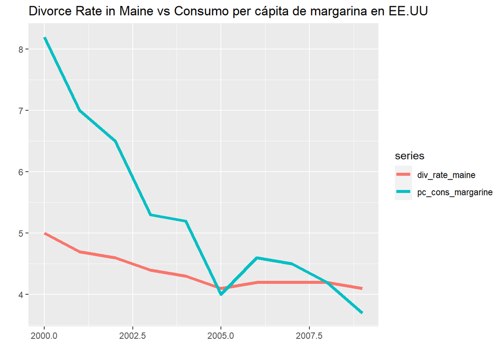

```r
# Subimos la base de datos:
ej_spou_regre = read_xlsx(file.choose())
View(ej_spou_regre)

#Convertirmos las variables en series de tiempo
div_rate_maine = ts(ej_spou_regre$Div_rate_Maine, start = c(2000), end = c(2009),
                    frequency = 1)

pc_cons_margarine = ts(ej_spou_regre$Pc_cons_margarine, start = c(2000), end = c(2009),
                       frequency = 1)

# Se grafican las series en un mismo plano:
autoplot(cbind(div_rate_maine, pc_cons_margarine), facets = F,
         main="Divorce Rate in Maine vs Consumo per cápita de margarina en EE.UU", xlab="", ylab="", size=1.5)
```

Es reconocible que, aunque no tengan una senda exactamente común, ambas series reflejan valores positivos. Aunque se observa que en el caso del consumo per cápita de margarina se obtiene una senda positiva por encima de la tasas de divorcio (ya que la primera tiene un punto de inicio superior a la segunda), sus movimientos se asimilan entre sí.

```r
# Generamos el modelo de regresión de tipo: y_t = x_t
sp_regression_ej = lm(formula = pc_cons_margarine ~ div_rate_maine)
stargazer(sp_regression_ej, type="text")
```

```
##
## ===============================================
##                         Dependent variable:
##                     ---------------------------
##                          pc_cons_margarine
## -----------------------------------------------
## div_rate_maine4.2             0.583*
##                               (0.191)
##
## div_rate_maine4.3             1.350**
##                               (0.257)
##
## div_rate_maine4.4             1.450**
##                               (0.257)
##
## div_rate_maine4.6            2.650***
##                               (0.257)
##
## div_rate_maine4.7            3.150***
##                               (0.257)
##
## div_rate_maine5              4.350***
##                               (0.257)
##
## Constant                     3.850***
##                               (0.148)
##
## -----------------------------------------------
## Observations                    10
## R2                             0.993
## Adjusted R2                    0.980
## Residual Std. Error       0.209 (df = 3)
## F Statistic            72.928*** (df = 6; 3)
## ===============================================
## Note:               *p<0.1; **p<0.05; ***p<0.01
```

Esto prueba que dos series que no tienen ninguna relación entre sí, pueden generar resultados que, aparentemente, revelen que sí existe algún tipo de cointegración, aunque no tenga sentido (no hay justificación teórica).

### Resumen de Cointegración

Existen varias metodologías de cointegración en la literatura

-ARDL

-Metodología de Engle-Granger

-Metodología de Johansen

En el curso se estudiaran la metodología de Engle-Granger (que es el procedimiento que veremos en el presente Script) y metodología de Johansen (que lo veremos luego de ver la metodología de VAR)

La metodología de cointegración ha tenido una fuerte acogida en la literatura de macroeconomía, en particular, los académicos y bancos centrales la han empleado para estudiar de manera exitosa las relaciones entre variables cambiarias y monetarias con el fin de formular teoría económica y orientar mejor el diseño de política pública.

Ejemplos de cointegración en la literatura: Hipótesis del ingreso permanente de Friedman Ley de precio único Unbiased forward rate hypothesis (Insesgadez en la tasa forward como predictor de la tasa spot futura de una moneda) Movimiento conjunto de una casta de divisas (e.g. de las principales divisas, de las monedas de AL, demás) Hipótesis de expectativas de la estructura temporal de la tasa de interés (ejemplo 1 del script) Paridad de poder adquisitivo (PPP) y arbitraje en el mercado de bienes (ejemplo 2 del script)

Revisar el capítulo 6.1 del Enders para profundizar sobre algunos ejemplos de cointegración entre variables que se puede encontrar en la literatura

# A. Expectations hypothesis: Hipótesis de expectativas de la estructura temporal de la tasa de interés

En economía financiera, existe la concepción de que las tasas de interés de corto y de largo plazo de los bonos de un mismo país tienden a tener un movimiento común. Un bono, se puede entender como ese instrumento/vehículo de financiación que utilizan los países para conseguir financiación extranjera

El análisis se centra en la explicación de la famosos Yield Curve de dichos bonos y en explicar su dinámica así como su pendiente. Existen diferentes teorías que intentan explicar este comportamiento común de las tasa de interés de dichos bonos.

Modelos de tasas de interés:

1. La teoría de expectativas en la estructura temporal: Teoría más famosa y más comúnmente empleada pero de la que se sabe que tiene complicaciones o está incompleta)
2. Liquidity preference hypothesis: La teoría por la preferencia por la liquidez argumenta que los inversionistas exigen una “prima” adicional de retorno para invertir en bonos de LP dado que los consideran más riesgosos que los bonos de corto plazo
3. Modelos dinámicos: Vasicek, Cox-Ingersoll-Ross

En general, se espera que las tasas de largo plazo sean mayores a las tasas de corto plazo y por ende una pendiente positiva de la famosa Yield Curve. Cuando la Yield Curve se invierte, entonces las tasas de CP son mayores a las tasas de LP. Cuando lo anterior ocurre, los inversionistas y agentes del mercado suelen asociar a dicha inversión en la Yiled Curve como un presagio de que algo va a ocurrir en la economía algunas personas inclusive asocian a dicha inversión de la Yield Curve como una señal de que una economía va a entrar en recesión (aunque este “hecho estilizado” no siempre se cumple o se observa en la realidad)

El presente es un ejemplo del libro Introduction to econometrics with R de Hanck, Arnold, Gerber y Schmelzer. Disponible en el siguiente link: https://www.econometrics-with-r.org/16-3-cointegration.html

Nota: https://www.econometrics-with-r.org/ es un libro online bastante interesante, en la medida que tiene los códigos en R adaptados a los ejemplos del libro Introduction to Econometrics by Stock and Watson (2015) por lo que van a poder encontrar material de muy buena calidad en diversos temas de econometría en general, por lo que se les recomienda bastante que revisen los temas del libro porque podrían encontrar códigos de su interés.

Para este ejemplo veremos la relacion entre la tasa de interés de corto plazo (Treasury bills a 3 meses) y la tasa de interés de largo plazo (Treasury bonds a 10 años) de los Estados Unidos. En caso de estar cointegradas las series, se esperaría que el spread entre estas dos tasas, que es básicamente la diferencia entre las dos tasas, sea una serie estacionaria. En algunos contextos, se utiliza la Treasury bills a 3 meses como la tasa libre de riesgo mientras que en otros se emplea la Treasury bonds a 10 años como la tasa libre de riesgo

Importación de la base de datos

La base de datos USMacroSWQ contiene diferentes series de tiempo relacionadas con variables macroeconómicas de interés de los Estados Unidos. En particular, contiene Series históricas de las tasas de interés de los bonos del Tesoro de los EE.UU. A 3 meses (TB3MS), a un año (GS1) y a 10 años (GS10)

```r
USMacroSWQ <- read_xlsx(file.choose(),sheet = 1,col_types = c("text", rep("numeric", 9)))
view(USMacroSWQ)

# Formato de la columna fecha (date)
USMacroSWQ$...1 <- as.yearqtr(USMacroSWQ$...1, format = "%Y:0%q")
view(USMacroSWQ)

# Ajustamos nombres de las columnas
colnames(USMacroSWQ) <- c("Date", "GDPC96", "JAPAN_IP", "PCECTPI",
                          "GS10", "GS1", "TB3MS", "UNRATE", "EXUSUK", "CPIAUCSL")

# Visualización de la base de datos
glimpse(USMacroSWQ)
```

```
## Rows: 228
## Columns: 10
## $ Date     <yearqtr> 1957 Q1, 1957 Q2, 1957 Q3, 1957 Q4, 1958 Q1, 1958 Q2, 195…
## $ GDPC96   <dbl> 2851.778, 2845.453, 2873.169, 2843.718, 2770.000, 2788.278, 2…
## $ JAPAN_IP <dbl> 8.414363, 9.097347, 9.042708, 8.796834, 8.632918, 8.414363, 8…
## $ PCECTPI  <dbl> 16.449, 16.553, 16.687, 16.773, 16.978, 17.009, 17.022, 17.01…
## $ GS10     <dbl> 3.403333, 3.626667, 3.926667, 3.633333, 3.040000, 2.923333, 3…
## $ GS1      <dbl> 3.390000, 3.540000, 3.963333, 3.586667, 2.160000, 1.350000, 2…
## $ TB3MS    <dbl> 3.0966667, 3.1400000, 3.3533333, 3.3100000, 1.7566667, 0.9566…
## $ UNRATE   <dbl> 3.933333, 4.100000, 4.233333, 4.933333, 6.300000, 7.366667, 7…
## $ EXUSUK   <dbl> NA, NA, NA, NA, NA, NA, NA, NA, 2.809507, 2.814537, 2.808283,…
## $ CPIAUCSL <dbl> 27.77667, 28.01333, 28.26333, 28.40000, 28.73667, 28.93000, 2…
```

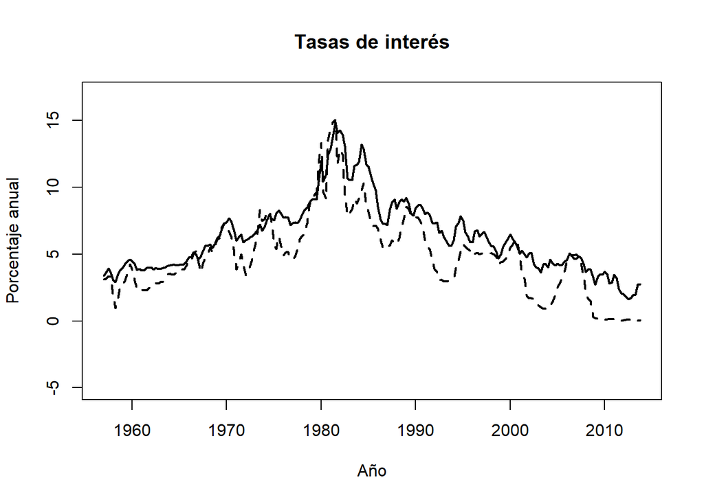

```r
view(USMacroSWQ)

# Tasa de interés 3-months Treasury bills
TB3MS = ts(USMacroSWQ$TB3MS, start = c(1957,1), end = c(2013,4), frequency = 4)
# Tasa de interés 10-years Treasury bonds
TB10YS = ts(USMacroSWQ$GS10,start = c(1957,1), end = c(2013,4), frequency = 4)


# Se analiza el comportamiento gráfico de las dos tasas
x11()
plot(merge(as.zoo(TB3MS), as.zoo(TB10YS)),
     plot.type = "single",
     lty = c(2, 1),
     lwd = 2,
     xlab = "Año",
     ylab = "Porcentaje anual",
     ylim = c(-5, 17),
     main = "Tasas de interés")
```

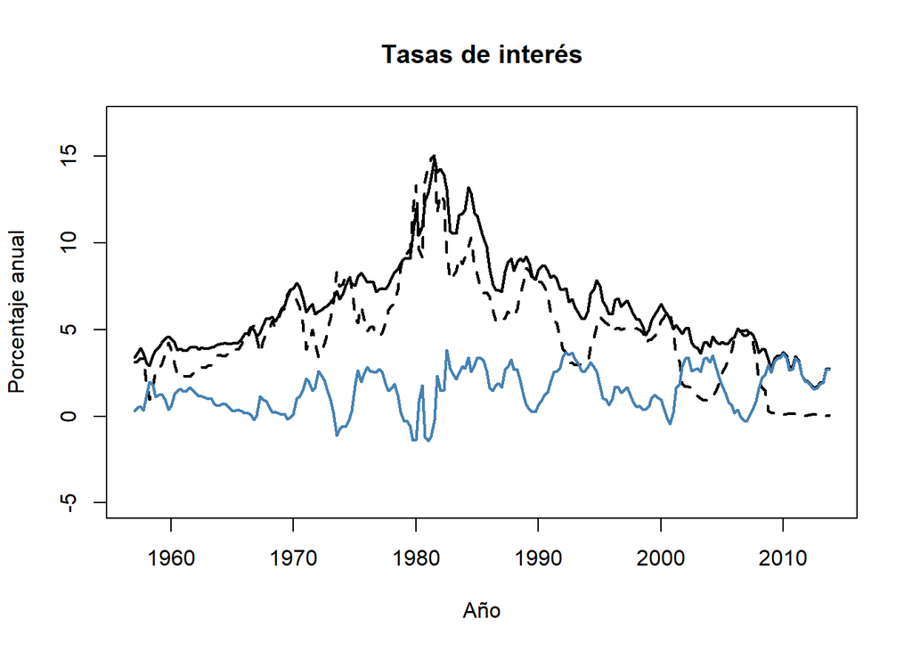

```r
# Ahora se grafica el spread de las dos tasas en la misma gráfica.
x11()
plot(merge(as.zoo(TB3MS), as.zoo(TB10YS)),
     plot.type = "single",
     lty = c(2, 1),
     lwd = 2,
     xlab = "Año",
     ylab = "Porcentaje anual",
     ylim = c(-5, 17),
     main = "Tasas de interés")
lines(as.zoo(TB10YS-TB3MS),
      col = "steelblue",
      lwd = 2,
      xlab = "Año",
      ylab = "Porcentaje anual")
```

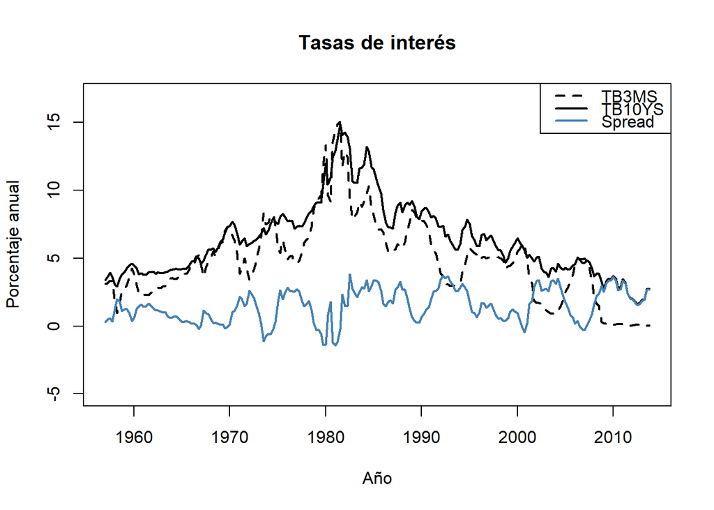

```r
# Se añade la leyenda
x11()
plot(merge(as.zoo(TB3MS), as.zoo(TB10YS)),
     plot.type = "single",
     lty = c(2, 1),
     lwd = 2,
     xlab = "Año",
     ylab = "Porcentaje anual",
     ylim = c(-5, 17),
     main = "Tasas de interés")
lines(as.zoo(TB10YS-TB3MS),
      col = "steelblue",
      lwd = 2,
      xlab = "Año",
      ylab = "Porcentaje anual")
legend("topright",
       legend = c("TB3MS", "TB10YS", "Spread"),
       col = c("black", "black", "steelblue"),
       lwd = c(2, 2, 2),
       lty = c(2, 1, 1))
```

Del anterior gráfico es posible concluir que las series posiblemente están cointegradas, en tanto: las series en nivel aparentemente son I(1) (aparentan tener una tendencia estocástica común), y finalmente, el spread entre ellas parece ser estacionario (la combinación lineal entre ambas parece eliminar la tendencia estocástica)

A nivel económico la anterior gráfica da bastante información relevante. Observar el comportamiento de las tasas de interés de los Estados Unidos dice bastante sobre la política monetaria que condujó la FED y el estado la economía norteaméricana. Por ejemplo, Se puede observar como en los 80s Volcker aumentó fuertemente las tasas de interés de EE.UU. para combatir la inflación, lo que tuvó fuertes consecuencias en crecimiento y pagos de la deuda en los países de América Latina. También, muestra las bajas tasas de interés de la FED luego de la crisis sub-prime del 2008

## Metodología Engle & Granger para la hipótesis de expectativas:

## Paso 1: Uso de la prueba ADF y KPSS sobre las series

### 1.1 ADF y KPSS sobre la tasa de interés de los T-Bills a 3 meses

Hay dos tipos de pruebas importantes que se emplea comúnente en la literatura para inverstigar si una serie tiene o no tiene raíz unitaria:

1. La familia de las pruebas tipo ADF donde la hipótesis nula es no estacionariedad
2. La familia de pruebas donde la hipótesis nula es estacionariedad. La más famosas de este tipo de prueba es la prueba KPSS

Nota: En la práctica es muy usual emplear al menos estas dos tipos de prueba para verificar la estacionariedad de una serie, de tal forma que se puedea obtener una diagnóstico más profundo del comportamiento de la serie y de si presenta o no una tendencia estocástica la serie de tiempo.

Primero vamos a hacer una prueba de ADF con tendencia e intercepto. Los valores críticos de la prueba son sensibles a la inclusión de términos determinísticos, de manera que hay que determinar si la serie tiene tendencia y/o intercepto.

El tau me dice si la serie tiene o no al menos una raíz unitaria. El phi3 me dice si la tendecia es significativa o no, y por tanto, si el el test de raíz unitaria debería incluir o no tendencia.

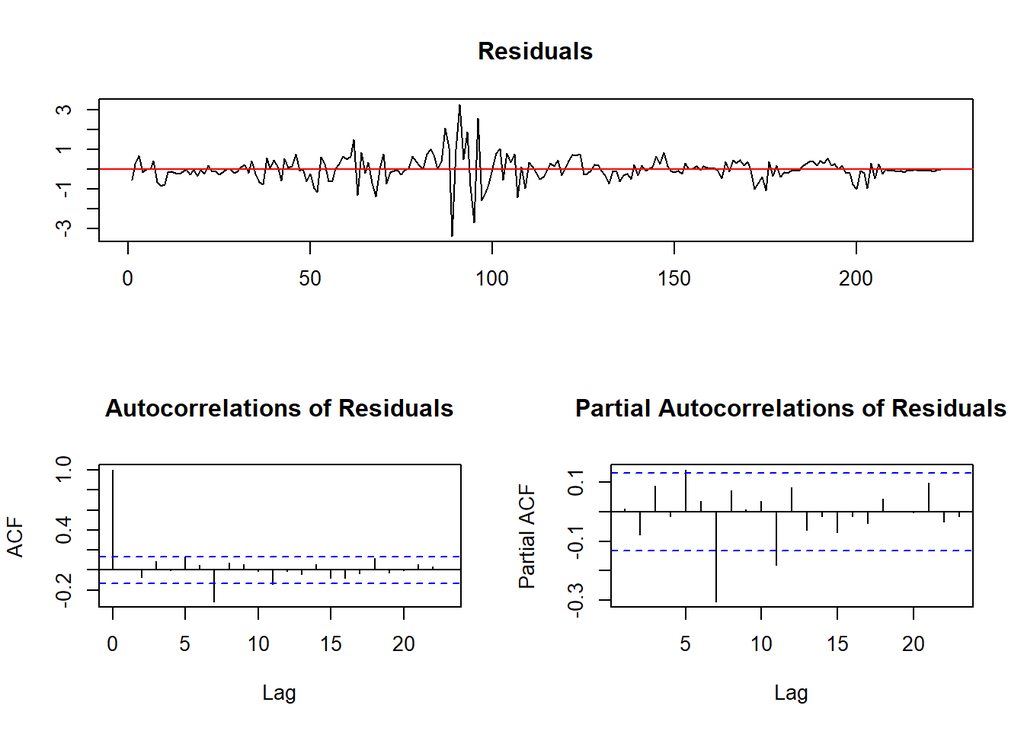

```r
adf1 = ur.df(TB3MS, lags=4, type = "trend"); plot(adf1)
```

```r
summary(adf1)
```

```
##
## ###############################################
## # Augmented Dickey-Fuller Test Unit Root Test #
## ###############################################
##
## Test regression trend
##
##
## Call:
## lm(formula = z.diff ~ z.lag.1 + 1 + tt + z.diff.lag)
##
## Residuals:
##     Min      1Q  Median      3Q     Max
## -3.3870 -0.2212 -0.0289  0.2856  3.2669
##
## Coefficients:
##              Estimate Std. Error t value Pr(>|t|)
## (Intercept)  0.343993   0.137750   2.497   0.0133 *
## z.lag.1     -0.040801   0.016237  -2.513   0.0127 *
## tt          -0.001280   0.000724  -1.768   0.0784 .
## z.diff.lag1  0.389581   0.066049   5.898 1.40e-08 ***
## z.diff.lag2 -0.327951   0.068636  -4.778 3.27e-06 ***
## z.diff.lag3  0.313895   0.067704   4.636 6.14e-06 ***
## z.diff.lag4 -0.080505   0.066894  -1.203   0.2301
## ---
## Signif. codes:  0 '***' 0.001 '**' 0.01 '*' 0.05 '.' 0.1 ' ' 1
##
## Residual standard error: 0.6649 on 216 degrees of freedom
## Multiple R-squared:  0.2138, Adjusted R-squared:  0.192
## F-statistic: 9.792 on 6 and 216 DF,  p-value: 1.522e-09
##
##
## Value of test-statistic is: -2.5129 2.5342 3.7962
##
## Critical values for test statistics:
##       1pct  5pct 10pct
## tau3 -3.99 -3.43 -3.13
## phi2  6.22  4.75  4.07
## phi3  8.43  6.49  5.47
```

El tau nos dice que la serie tiene al menos una raíz unitaria, mientras el phi3 nos dice que la tendencia no es significativa. Por lo tanto, vamos a mirar únicamente la prueba con intercepto.

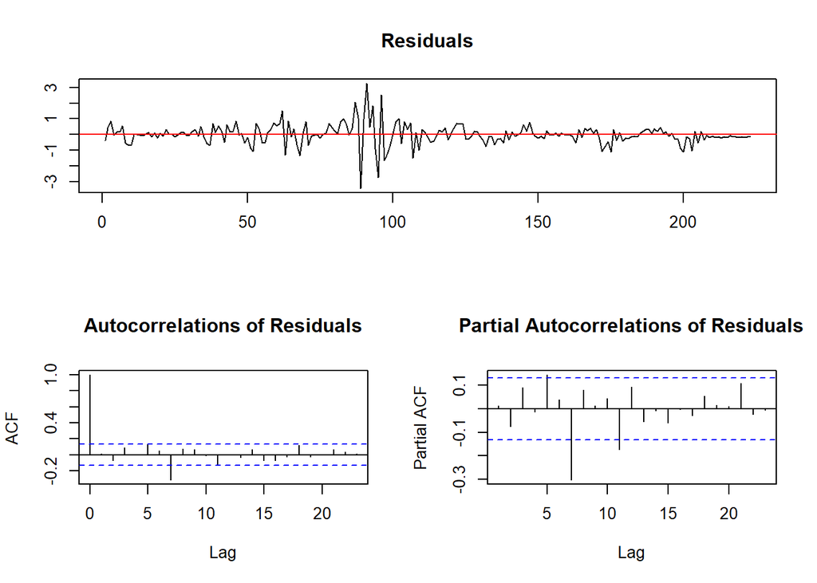

```r
adf2 = ur.df(TB3MS, lags=4, type = "drift"); plot(adf2)
```

```r
summary(adf2)
```

```
##
## ###############################################
## # Augmented Dickey-Fuller Test Unit Root Test #
## ###############################################
##
## Test regression drift
##
##
## Call:
## lm(formula = z.diff ~ z.lag.1 + 1 + z.diff.lag)
##
## Residuals:
##     Min      1Q  Median      3Q     Max
## -3.4288 -0.2137 -0.0162  0.2684  3.2543
##
## Coefficients:
##             Estimate Std. Error t value Pr(>|t|)
## (Intercept)  0.15768    0.08917   1.768   0.0784 .
## z.lag.1     -0.03303    0.01571  -2.103   0.0366 *
## z.diff.lag1  0.39309    0.06634   5.925 1.21e-08 ***
## z.diff.lag2 -0.32842    0.06897  -4.762 3.51e-06 ***
## z.diff.lag3  0.31722    0.06801   4.664 5.41e-06 ***
## z.diff.lag4 -0.08006    0.06722  -1.191   0.2350
## ---
## Signif. codes:  0 '***' 0.001 '**' 0.01 '*' 0.05 '.' 0.1 ' ' 1
##
## Residual standard error: 0.6682 on 217 degrees of freedom
## Multiple R-squared:  0.2025, Adjusted R-squared:  0.1841
## F-statistic: 11.02 on 5 and 217 DF,  p-value: 1.819e-09
##
##
## Value of test-statistic is: -2.1029 2.216
##
## Critical values for test statistics:
##       1pct  5pct 10pct
## tau2 -3.46 -2.88 -2.57
## phi1  6.52  4.63  3.81
```

Los resultados indican que la serie tiene al menos una raíz unirtaria. El phi1, por su parte, indica que la deriva de la serie no es significativa, por tanto, debe hacerse una prueba sin deriva

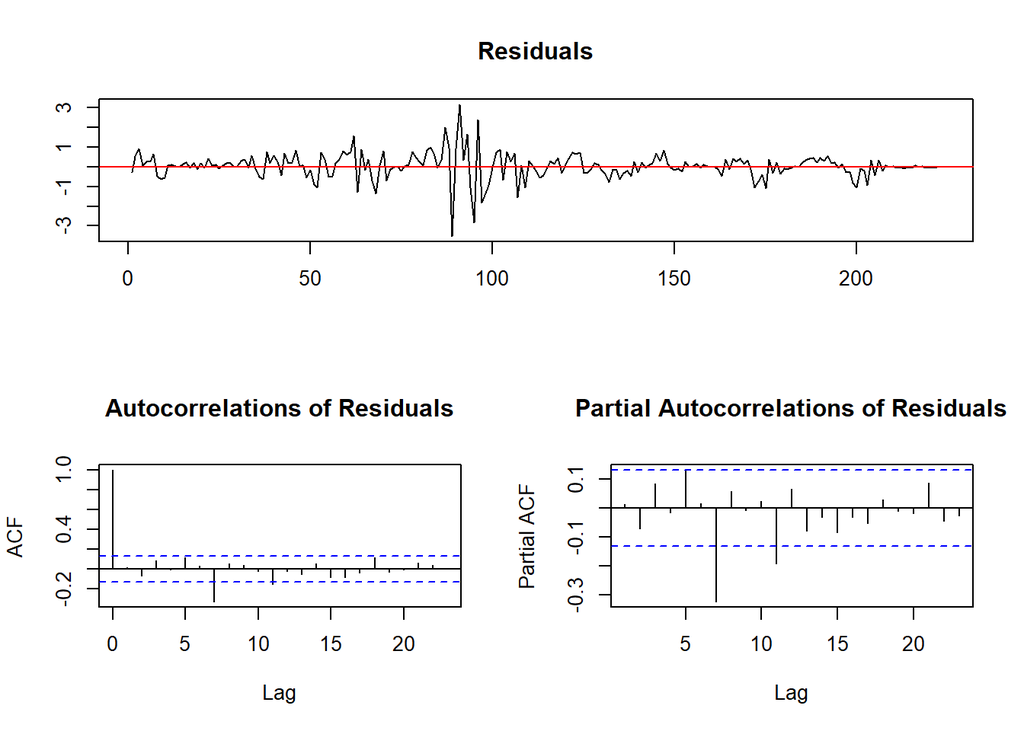

```r
#Esta es la correcta especificación de la prueba dado que los términos determinísticos no son significativos.
adf3 = ur.df(TB3MS,lags=4, type = "none"); plot(adf3)
```

```r
summary(adf3)
```

```
##
## ###############################################
## # Augmented Dickey-Fuller Test Unit Root Test #
## ###############################################
##
## Test regression none
##
##
## Call:
## lm(formula = z.diff ~ z.lag.1 - 1 + z.diff.lag)
##
## Residuals:
##     Min      1Q  Median      3Q     Max
## -3.5317 -0.1680  0.0470  0.3174  3.1688
##
## Coefficients:
##              Estimate Std. Error t value Pr(>|t|)
## z.lag.1     -0.009009   0.007925  -1.137    0.257
## z.diff.lag1  0.383594   0.066446   5.773 2.66e-08 ***
## z.diff.lag2 -0.348403   0.068370  -5.096 7.52e-07 ***
## z.diff.lag3  0.308488   0.068159   4.526 9.88e-06 ***
## z.diff.lag4 -0.099678   0.066621  -1.496    0.136
## ---
## Signif. codes:  0 '***' 0.001 '**' 0.01 '*' 0.05 '.' 0.1 ' ' 1
##
## Residual standard error: 0.6714 on 218 degrees of freedom
## Multiple R-squared:  0.1911, Adjusted R-squared:  0.1725
## F-statistic:  10.3 on 5 and 218 DF,  p-value: 7.077e-09
##
##
## Value of test-statistic is: -1.1369
##
## Critical values for test statistics:
##       1pct  5pct 10pct
## tau1 -2.58 -1.95 -1.62
```

Hacemos la prueba KPSS cuya hipótesis nula es que la serie es estacionaria, la cual es totalmente contraria a la ADF. Se toman 4 rezagos porque fueron los mismos utilizados en las pruebas ADF.

```r
kp1 = ur.kpss(TB3MS, use.lag = 4, type = "mu") #el mu nos indica que es una prueba sin términos determinísticos.
summary(kp1)
```

```
##
## #######################
## # KPSS Unit Root Test #
## #######################
##
## Test is of type: mu with 4 lags.
##
## Value of test-statistic is: 1.1369
##
## Critical value for a significance level of:
##                 10pct  5pct 2.5pct  1pct
## critical values 0.347 0.463  0.574 0.739
```

Claramente rechazamos la hipótesis nula de estacionariedad, así que la serie de la tasa de interés de los treasury bills a 3 meses no es estacionaria.

### 1.2 ADF y KPSS sobre la tasa de interés de los T-Bonds a 10 años

Primero vamos a hacer una prueba de ADF con tendencia e intercepto. Los valores críticos de la prueba son sensibles a la inclusión de términos determinísticos, de manera que hay que determinar si la serie tiene tendencia y/o intercepto.

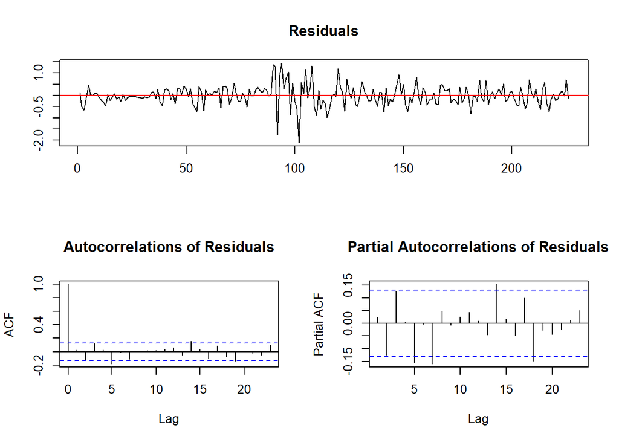

```r
adf4 = ur.df(TB10YS,lags=1, type = "trend"); plot(adf4)
```

```r
summary(adf4)
```

```
##
## ###############################################
## # Augmented Dickey-Fuller Test Unit Root Test #
## ###############################################
##
## Test regression trend
##
##
## Call:
## lm(formula = z.diff ~ z.lag.1 + 1 + tt + z.diff.lag)
##
## Residuals:
##      Min       1Q   Median       3Q      Max
## -2.12209 -0.25599 -0.02222  0.24550  1.43818
##
## Coefficients:
##               Estimate Std. Error t value Pr(>|t|)
## (Intercept)  0.2033201  0.1018862   1.996 0.047204 *
## z.lag.1     -0.0202196  0.0114883  -1.760 0.079781 .
## tt          -0.0006818  0.0004779  -1.427 0.155063
## z.diff.lag   0.2407229  0.0650546   3.700 0.000272 ***
## ---
## Signif. codes:  0 '***' 0.001 '**' 0.01 '*' 0.05 '.' 0.1 ' ' 1
##
## Residual standard error: 0.4614 on 222 degrees of freedom
## Multiple R-squared:  0.07627,    Adjusted R-squared:  0.06379
## F-statistic:  6.11 on 3 and 222 DF,  p-value: 0.0005189
##
##
## Value of test-statistic is: -1.76 1.5092 2.2585
##
## Critical values for test statistics:
##       1pct  5pct 10pct
## tau3 -3.99 -3.43 -3.13
## phi2  6.22  4.75  4.07
## phi3  8.43  6.49  5.47
```

El tau nos dice que la serie tiene al menos una raíz unitaria, mientras el phi3 nos dice que la tendencia no es significativa. Por lo tanto, vamos a mirar únicamente la prueba con intercepto.

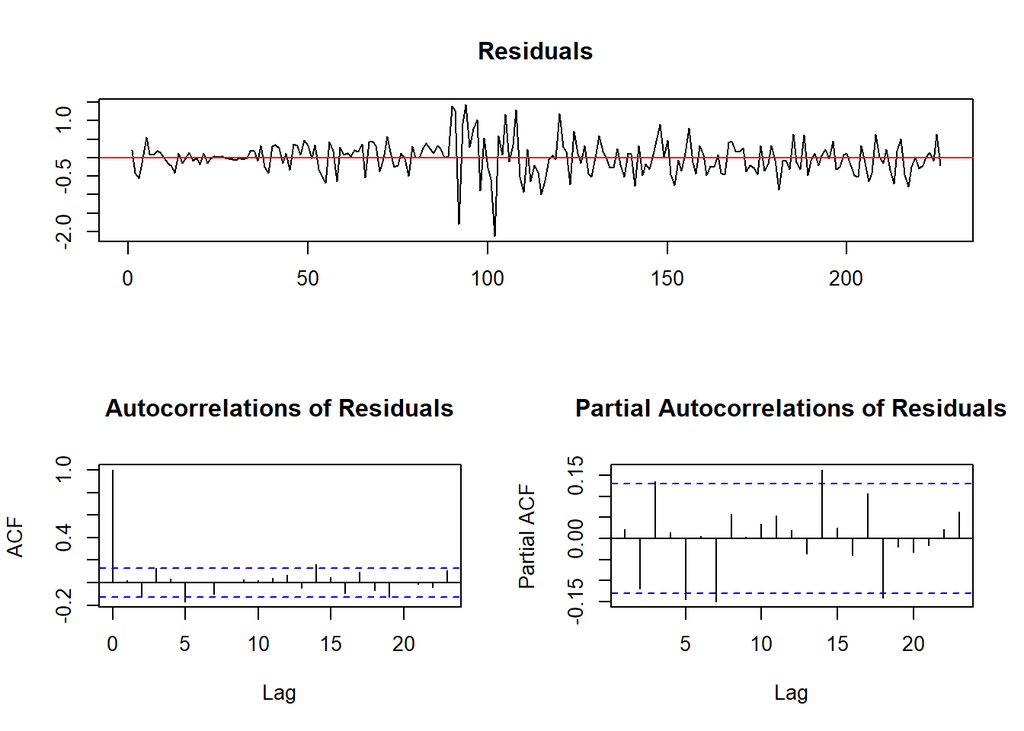

```r
adf5 = ur.df(TB10YS, lags=1, type = "drift"); plot(adf5)
```

```r
summary(adf5)
```

```
##
## ###############################################
## # Augmented Dickey-Fuller Test Unit Root Test #
## ###############################################
##
## Test regression drift
##
##
## Call:
## lm(formula = z.diff ~ z.lag.1 + 1 + z.diff.lag)
##
## Residuals:
##      Min       1Q   Median       3Q      Max
## -2.12281 -0.26002  0.00389  0.24908  1.43673
##
## Coefficients:
##             Estimate Std. Error t value Pr(>|t|)
## (Intercept)  0.11066    0.07868   1.406  0.16101
## z.lag.1     -0.01792    0.01140  -1.572  0.11746
## z.diff.lag   0.24938    0.06492   3.841  0.00016 ***
## ---
## Signif. codes:  0 '***' 0.001 '**' 0.01 '*' 0.05 '.' 0.1 ' ' 1
##
## Residual standard error: 0.4625 on 223 degrees of freedom
## Multiple R-squared:  0.0678, Adjusted R-squared:  0.05944
## F-statistic:  8.11 on 2 and 223 DF,  p-value: 0.0003983
##
##
## Value of test-statistic is: -1.5716 1.2403
##
## Critical values for test statistics:
##       1pct  5pct 10pct
## tau2 -3.46 -2.88 -2.57
## phi1  6.52  4.63  3.81
```

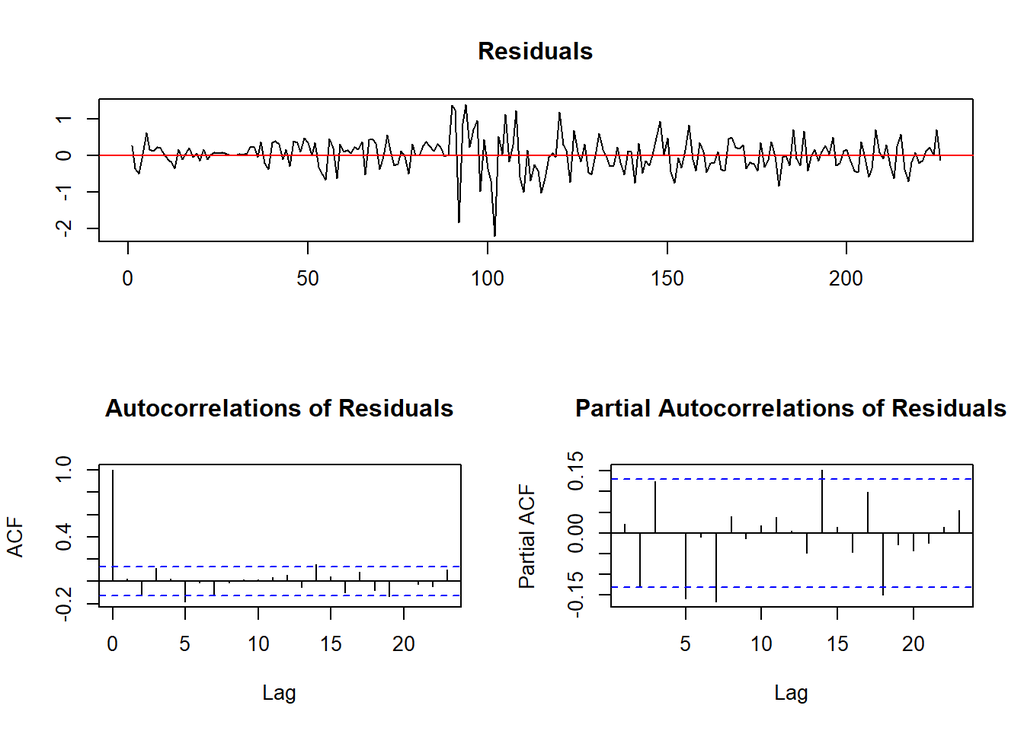

```r
#Esta es la correcta especificación de la prueba dado que los términos determinísticos no son significativos.
adf6 =  ur.df(TB10YS, lags=1, type = "none"); plot(adf6)
```

```r
summary(adf6)
```

```
##
## ###############################################
## # Augmented Dickey-Fuller Test Unit Root Test #
## ###############################################
##
## Test regression none
##
##
## Call:
## lm(formula = z.diff ~ z.lag.1 - 1 + z.diff.lag)
##
## Residuals:
##      Min       1Q   Median       3Q      Max
## -2.21243 -0.25255  0.03715  0.26425  1.38969
##
## Coefficients:
##             Estimate Std. Error t value Pr(>|t|)
## z.lag.1    -0.003161   0.004468  -0.707 0.480009
## z.diff.lag  0.241117   0.064795   3.721 0.000251 ***
## ---
## Signif. codes:  0 '***' 0.001 '**' 0.01 '*' 0.05 '.' 0.1 ' ' 1
##
## Residual standard error: 0.4635 on 224 degrees of freedom
## Multiple R-squared:  0.0596, Adjusted R-squared:  0.0512
## F-statistic: 7.098 on 2 and 224 DF,  p-value: 0.001026
##
##
## Value of test-statistic is: -0.7075
##
## Critical values for test statistics:
##       1pct  5pct 10pct
## tau1 -2.58 -1.95 -1.62
```

Claramente se evidencia que la serie tiene al menos una raíz unitaria, en tanto no se rechaza la hipótesis nula. Noten la importancia de determinar si la serie tiene términos detemrminísticos, pues el valor calculado en cada especificación de la prueba cambió de forma importante.

```r
#Hacemos la prueba KPSS cuya hipótesis nula es que la serie es estacionaria, la cual es totalmente contraria a la ADF.
kp2 = ur.kpss(TB10YS, use.lag = 1, type = "mu") #el mu nos indica que es una prueba sin términos determinísticos.
summary(kp2)
```

```
##
## #######################
## # KPSS Unit Root Test #
## #######################
##
## Test is of type: mu with 1 lags.
##
## Value of test-statistic is: 2.5985
##
## Critical value for a significance level of:
##                 10pct  5pct 2.5pct  1pct
## critical values 0.347 0.463  0.574 0.739
```

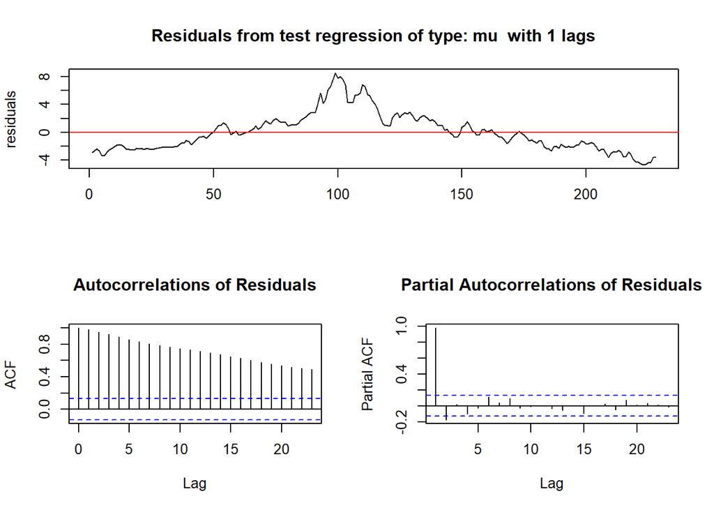

```r
plot(kp2)
```

Claramente rechazamos la hipótesis nula de estacionariedad, así que las serie tiene al menos una raíz unitaria.

```r
#Hacemos la prueba ADF sobre las series diferenciadas para confirmar que son I(0)
adf8 = ur.df(diff(TB3MS), lag=2, type = "none"); summary(adf8) #Estacionaria.
```

```
##
## ###############################################
## # Augmented Dickey-Fuller Test Unit Root Test #
## ###############################################
##
## Test regression none
##
##
## Call:
## lm(formula = z.diff ~ z.lag.1 - 1 + z.diff.lag)
##
## Residuals:
##     Min      1Q  Median      3Q     Max
## -3.6496 -0.2070  0.0161  0.2837  3.0092
##
## Coefficients:
##             Estimate Std. Error t value Pr(>|t|)
## z.lag.1     -0.69999    0.09957  -7.030 2.54e-11 ***
## z.diff.lag1  0.05410    0.07790   0.695    0.488
## z.diff.lag2 -0.26926    0.06477  -4.157 4.61e-05 ***
## ---
## Signif. codes:  0 '***' 0.001 '**' 0.01 '*' 0.05 '.' 0.1 ' ' 1
##
## Residual standard error: 0.68 on 221 degrees of freedom
## Multiple R-squared:  0.4636, Adjusted R-squared:  0.4564
## F-statistic: 63.68 on 3 and 221 DF,  p-value: < 2.2e-16
##
##
## Value of test-statistic is: -7.0302
##
## Critical values for test statistics:
##       1pct  5pct 10pct
## tau1 -2.58 -1.95 -1.62
```

```r
adf7 = ur.df(diff(TB10YS), lag=1, type = "none"); summary(adf7) #Estacionaria
```

```
##
## ###############################################
## # Augmented Dickey-Fuller Test Unit Root Test #
## ###############################################
##
## Test regression none
##
##
## Call:
## lm(formula = z.diff ~ z.lag.1 - 1 + z.diff.lag)
##
## Residuals:
##      Min       1Q   Median       3Q      Max
## -2.27358 -0.27866  0.01264  0.24526  1.34667
##
## Coefficients:
##            Estimate Std. Error t value Pr(>|t|)
## z.lag.1    -0.84096    0.08223 -10.226   <2e-16 ***
## z.diff.lag  0.10459    0.06687   1.564    0.119
## ---
## Signif. codes:  0 '***' 0.001 '**' 0.01 '*' 0.05 '.' 0.1 ' ' 1
##
## Residual standard error: 0.4623 on 223 degrees of freedom
## Multiple R-squared:  0.3879, Adjusted R-squared:  0.3824
## F-statistic: 70.65 on 2 and 223 DF,  p-value: < 2.2e-16
##
##
## Value of test-statistic is: -10.2263
##
## Critical values for test statistics:
##       1pct  5pct 10pct
## tau1 -2.58 -1.95 -1.62
```

Ambas series son ahora estacionarias.

## Paso 2: Estimación de los residuales de la regresión en niveles

La teoría económica (teoría de expectativas de la estructura temporal de las tasas de interés) sugiere que el vector de cointegración es -1. Para corroborar lo anterior empíricamente, se empieza encontrando el valor del vector de cointegración.

El comando dynlm: Me permite estimar estimar modelos lineales dinámicos Incluyendo modelos dinámicos de series de tiempo. Modelos que permite estimar: MCO, MCO Dinámicos (DOLS), modelos de corrección de error. Funciona tanto con objetos ts como con objetos zoo

Nota:

TB3MS: Tasa de interés de los T-bills de EE.UU. a 3 meses

TB10YS: Tasa de interés de los Treasury bones de los EE.UU. a 10 años

### 2.1 Estimación por MCO: —-

Test de cointegración de Engle-Granger: Pasos:

1. Estimar por MCO o por MCOD (DOLS) el parámetro de cointegración entre las dos series que se creen que están cointegradas
2. Recuperar los residuales de la regresión anterior
3. Efectuar un test ADF sobre dichos residuales para saber si son o no son estacionarios. En caso de ser estacionarios, según el test de engle-granger las series están cointegradas y en caso de no ser estacionarios, entonces según este mismo test las series no están cointegradas.
4. Emplear los valores críticos modificados para el test de cointegración de Engle-Granger (e.g. ver la Tabla C. del manual suplementario del Enders). Si bien, los valores críticos cambian, la mecáncia del test de Engle-Granger para cointegración es la misma que se haría para una serie solo se que se aplica a los residuales de una regresión y se deben ajustar los valores críticos para el análisis

Si TB3MS y TB10YS son series I(1) y además están cointegradas, se puede estimar una regresión en niveles:  
El estimador de MCO de la regresión en niveles es consistente cuando yt y zt están cointegradas

```r
FS_EGADF <- dynlm(TB10YS ~ TB3MS)
summary(FS_EGADF)
```

```
##
## Time series regression with "ts" data:
## Start = 1957(1), End = 2013(4)
##
## Call:
## dynlm(formula = TB10YS ~ TB3MS)
##
## Residuals:
##     Min      1Q  Median      3Q     Max
## -2.0202 -0.9260 -0.1335  0.8691  3.0644
##
## Coefficients:
##             Estimate Std. Error t value Pr(>|t|)
## (Intercept)  2.31053    0.13647   16.93   <2e-16 ***
## TB3MS        0.83095    0.02402   34.60   <2e-16 ***
## ---
## Signif. codes:  0 '***' 0.001 '**' 0.01 '*' 0.05 '.' 0.1 ' ' 1
##
## Residual standard error: 1.087 on 226 degrees of freedom
## Multiple R-squared:  0.8412, Adjusted R-squared:  0.8405
## F-statistic:  1197 on 1 and 226 DF,  p-value: < 2.2e-16
```

También es posible encontrar los resultados de la regresión utilizando el comando tidy() del paquete broom

```r
tidy_FS_EGADF = tidy(FS_EGADF)
tidy_FS_EGADF
```

```
## # A tibble: 2 × 5
##   term        estimate std.error statistic  p.value
##   <chr>          <dbl>     <dbl>     <dbl>    <dbl>
## 1 (Intercept)    2.31     0.136       16.9 4.51e-42
## 2 TB3MS          0.831    0.0240      34.6 2.85e-92
```

Parámetro/vector de cointegración calculado por MCO:

```r
coint_param_MCO = tidy_FS_EGADF$estimate[2]; coint_param_MCO
```

```
## [1] 0.8309539
```

Se obtienen los residuales de la regresión

```r
z_hat <- residuals(FS_EGADF)
```

La idea, es verificar si los residuales de la regresión son estacionarios, es decir, si son I(0), porque de serlo se sabe que la serie de residuales seria estacionaria y por tanto las series estarian cointegradas

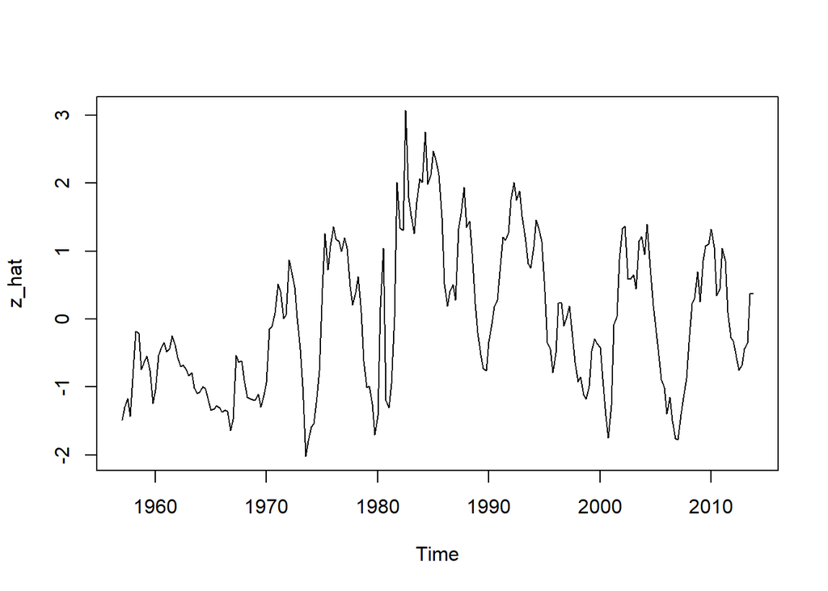

```r
# Graficamos los residuales y analizamos su ACF y PACF
x11()
plot.ts(z_hat)
```

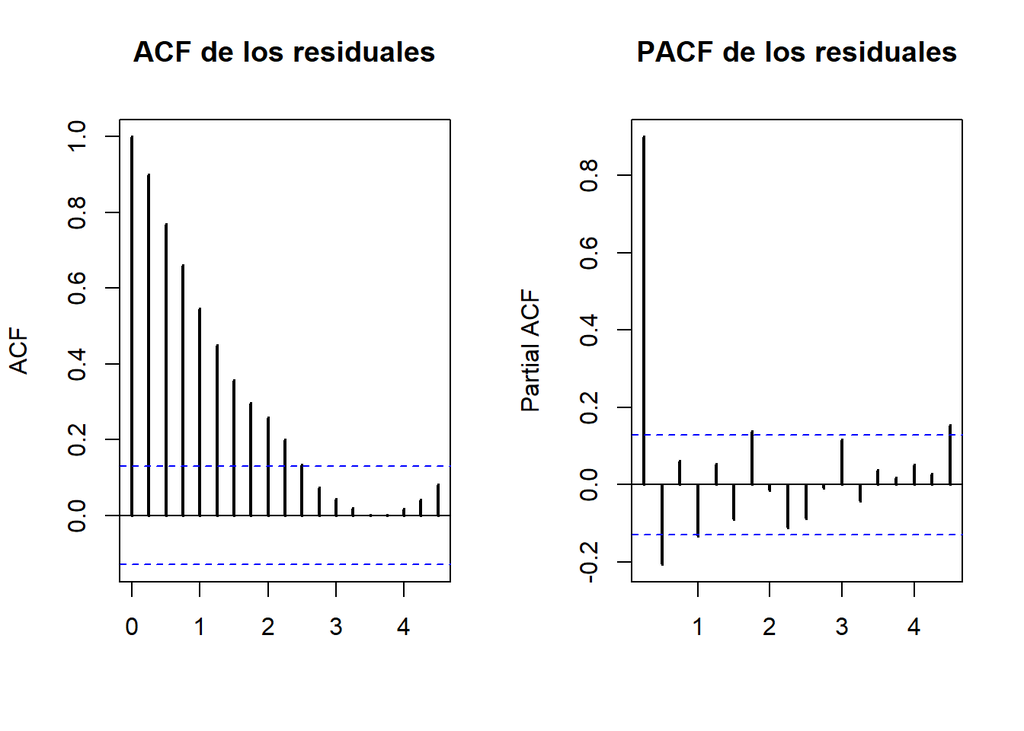

```r
lags = 18
par(mfrow=c(1,2))
acf(z_hat,lag.max=lags,plot=T,lwd=2,xlab='',main='ACF de los residuales')
pacf(z_hat,lag.max=lags,plot=T,lwd=2,xlab='',main='PACF de los residuales')
```

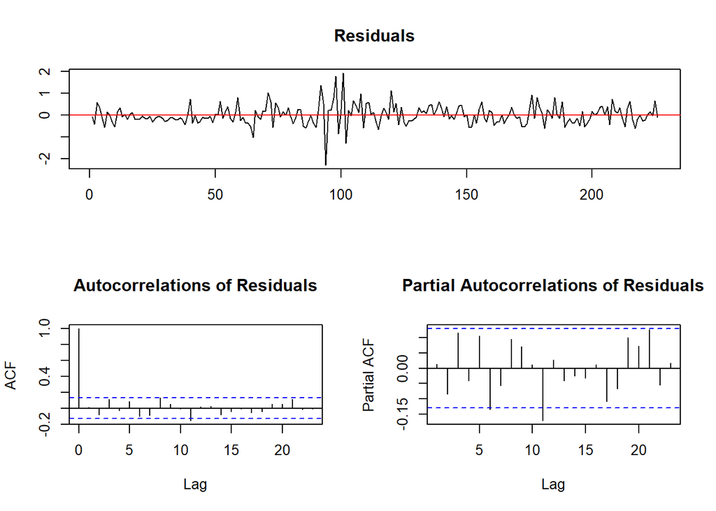

```
##
## ###############################################
## # Augmented Dickey-Fuller Test Unit Root Test #
## ###############################################
##
## Test regression none
##
##
## Call:
## lm(formula = z.diff ~ z.lag.1 - 1 + z.diff.lag)
##
## Residuals:
##      Min       1Q   Median       3Q      Max
## -2.29724 -0.24560 -0.04441  0.22835  1.92879
##
## Coefficients:
##            Estimate Std. Error t value Pr(>|t|)
## z.lag.1    -0.11975    0.02861  -4.185  4.1e-05 ***
## z.diff.lag  0.21510    0.06499   3.310  0.00109 **
## ---
## Signif. codes:  0 '***' 0.001 '**' 0.01 '*' 0.05 '.' 0.1 ' ' 1
##
## Residual standard error: 0.4551 on 224 degrees of freedom
## Multiple R-squared:  0.09558,    Adjusted R-squared:  0.0875
## F-statistic: 11.84 on 2 and 224 DF,  p-value: 1.299e-05
##
##
## Value of test-statistic is: -4.1851
##
## Critical values for test statistics:
##       1pct  5pct 10pct
## tau1 -2.58 -1.95 -1.62
```

```r
# Hacemos la prueba ADF sin términos determinísticos.
adf9 = ur.df(z_hat,lags=1,type = "none"); plot(adf9); summary(adf9) #Los residuales son estacionarios: hay cointegración.
```

No obstante, la prueba de ur.df ofrece valores críticos que no corresponden a los valores que se requieren para la prueba de cointegración a pesar de que las mecánica sea lo misma (Estimo por MCO la regresión entre TB10YS ~ TB3MS, cálculo los resdiduales de dicha regresión y realizo una prueba de ADF pero utilizando los valores críticos correctos (test de Engle-Granger))

Lo anterior, se debe a que los residuales fueron estimados (no son las verdaderas innovaciones porque no son conocidas) debido a que el vector de cointegración (el theta) en el caso univariado tuvo que ser estimado en la primer etapa

A la hora de calcular los valores criticos para la prueba de Engle-Granger hay que tener en cuenta tanto el numero de observaciones como variables que se encuentren en la relacion de cointegracion (número de variables cointegradas)

Para mas info ver enders 6.4 y el suppelementary manual

En el manual suplementario del Enders, en TABLE C: Critical Values for the Engle − Granger Cointegration Test se encuentran los valores críticos para efectuar un test de cointegración de Engle-Granger

También es posible ejecutar la prueba de cointegración de engle-granger de manera automática de una vez

```r
#El comando coint.test del paquete aTSA permite realizar los dos pasos de la prueba de cointegración

coint.test(TB10YS, TB3MS)
```

```
## Response: TB10YS
## Input: TB3MS
## Number of inputs: 1
## Model: y ~ X + 1
## -------------------------------
## Engle-Granger Cointegration Test
## alternative: cointegrated
##
## Type 1: no trend
##     lag      EG p.value
##    4.00   -4.21    0.01
## -----
##  Type 2: linear trend
##     lag      EG p.value
##   4.000   0.692   0.100
## -----
##  Type 3: quadratic trend
##     lag      EG p.value
##   4.000   0.626   0.100
## -----------
## Note: p.value = 0.01 means p.value <= 0.01
##     : p.value = 0.10 means p.value >= 0.10
```

El comando da tres resultados diferentes (para este ejemplo se usara el valor de type1)

-type1 es para prueba sin tendencia determinística

-type2 es para prueba con tendencia lineal

-type3 es para prueba con tendencia cuadrática

nlag: número de rezagos para la prueba de ADF (Generalmente el comando escoge automáticamente el numero de rezagos a usar)

El test Type1: no trend, muestra que se rechaza la hipótesis nula de no cointegración a favor de la hipótesis alternativa de que las series están cointegradas (que es equivalente a que los residuales de la primera etapa o primera regresión son estacionarios)

Nota: A veces el test de cointegración de engle-granger puede no dar cointegración en una dirección de las variables,es decir en x ~ y, pero en la otra dirección sí puede dar cointegración y ~ x, o viceversa. Por tanto, es importante que estimen ambas relaciones y miren si en alguno da que las series están cointegradas, basta con que una de ellas muestre cointegración. Una de las devesventajas de la metodología de Engle-Granger es que no es claro el orden de las variables en la relación y es necesario establecer un “orden” (además de solo poder establecer una relación de cointegración a la vez). La metodología de Johansen (que veremos más adelante) es más general en la medida de que:

1. no necesita ningún “orden” en las variables para analizar su vector de cointegración
2. me estima varias reaciones de cointegración entre más de dos variables (en casi de existir dichas relaciones)

```r
# numero de datos a la hora de realizar el test de cointegracion
length(TB10YS)
```

```
## [1] 228
```

##Paso 3: Regresión con variables cointegradas —-

### 3.1 Modelo de Minimos Cuadrados Ordinarios Dinámicos —-

Ahora bien, en la práctica es mucho más usual realizar un modelo de Mínimos cuadrados dinámicos (MCOD) o DOLS (Dynamic Ordinary Least Squares), dado que a pesar de que cuando las series están cointegradas MCO es una metodología consistente, se tiene que MCO tiene una distribución no normal por lo que la inferencia estadística no es válida.

Se prefiere emplear MCOD sobre MCO para cálcular el parámetro de cointegración, por dos razones: 1. Inferencia estadísticas válida acerca de dicho parámetro puede realizarse incluyendo valores pasados, presentes y futuros de delta y_t y usando erroes estándar robustos HAC

2. Al permitir incluir valores pasados, presentes y futuros, da mayor flexibilidad a la estimación y por tanto una mayor precisión en la estimación del parámetro de cointegración

Asumiremos que hay un máximo de 6 rezagos, por lo tanto, miraremos cuál tiene el menor AIC.La selección del modelo DOLS a emplear, también se basa en el que minimice el criterio AIC (tal como se hacía cuando se seleccionaban modelos ARIMA usando criterios de información) d(x, k) significa diferencia, donde k implica el orden de la diferencia (por default k = 1) es decir d(x, k) es equivalente a diff(x, lag = k) dentro del comando dynlm L significa rezagos. Así L(d(TB3MS),-1:1)) significa incluya los adelantes y rezagos de la primera diferencia de TB3MS. -1 esta asociado con el adelanto mientras que 1 con el rezago

Ojo con los signos! -1 denota un adelanto en la serie (un paso adelante) y 1 denota un rezago (un paso atrás tal y como se ve rezagos/lags en clase)

Tener en cuenta que para un modelo dinámico es necesario incluir tanto rezagos como adelantos Para que la inferencia sea válida

```r
FS_MCOD1 = dynlm(TB10YS ~ TB3MS + L(d(TB3MS),-1:1)); summary(FS_MCOD1)
```

```
##
## Time series regression with "ts" data:
## Start = 1957(3), End = 2013(3)
##
## Call:
## dynlm(formula = TB10YS ~ TB3MS + L(d(TB3MS), -1:1))
##
## Residuals:
##     Min      1Q  Median      3Q     Max
## -2.0026 -0.8412 -0.1593  0.8174  2.9340
##
## Coefficients:
##                     Estimate Std. Error t value Pr(>|t|)
## (Intercept)          2.15541    0.13081  16.477  < 2e-16 ***
## TB3MS                0.86302    0.02306  37.433  < 2e-16 ***
## L(d(TB3MS), -1:1)-1  0.03290    0.09622   0.342 0.732722
## L(d(TB3MS), -1:1)0  -0.32740    0.09754  -3.357 0.000929 ***
## L(d(TB3MS), -1:1)1  -0.42229    0.09671  -4.366 1.94e-05 ***
## ---
## Signif. codes:  0 '***' 0.001 '**' 0.01 '*' 0.05 '.' 0.1 ' ' 1
##
## Residual standard error: 1.004 on 220 degrees of freedom
## Multiple R-squared:  0.8658, Adjusted R-squared:  0.8633
## F-statistic: 354.7 on 4 and 220 DF,  p-value: < 2.2e-16
```

```r
FS_MCOD2 = dynlm(TB10YS ~ TB3MS + L(d(TB3MS),-2:2)); summary(FS_MCOD2)
```

```
##
## Time series regression with "ts" data:
## Start = 1957(4), End = 2013(2)
##
## Call:
## dynlm(formula = TB10YS ~ TB3MS + L(d(TB3MS), -2:2))
##
## Residuals:
##     Min      1Q  Median      3Q     Max
## -1.7221 -0.7494 -0.1442  0.7144  2.7962
##
## Coefficients:
##                     Estimate Std. Error t value Pr(>|t|)
## (Intercept)          2.05059    0.13007  15.765  < 2e-16 ***
## TB3MS                0.88414    0.02298  38.476  < 2e-16 ***
## L(d(TB3MS), -2:2)-2  0.08033    0.09832   0.817  0.41483
## L(d(TB3MS), -2:2)-1  0.12506    0.10311   1.213  0.22650
## L(d(TB3MS), -2:2)0  -0.44608    0.10498  -4.249 3.19e-05 ***
## L(d(TB3MS), -2:2)1  -0.30917    0.10332  -2.992  0.00309 **
## L(d(TB3MS), -2:2)2  -0.41739    0.09767  -4.273 2.89e-05 ***
## ---
## Signif. codes:  0 '***' 0.001 '**' 0.01 '*' 0.05 '.' 0.1 ' ' 1
##
## Residual standard error: 0.9677 on 216 degrees of freedom
## Multiple R-squared:  0.8762, Adjusted R-squared:  0.8728
## F-statistic: 254.8 on 6 and 216 DF,  p-value: < 2.2e-16
```

```r
FS_MCOD3 = dynlm(TB10YS ~ TB3MS + L(d(TB3MS),-3:3)); summary(FS_MCOD3)
```

```
##
## Time series regression with "ts" data:
## Start = 1958(1), End = 2013(1)
##
## Call:
## dynlm(formula = TB10YS ~ TB3MS + L(d(TB3MS), -3:3))
##
## Residuals:
##     Min      1Q  Median      3Q     Max
## -1.5471 -0.7263 -0.2356  0.6887  3.1952
##
## Coefficients:
##                     Estimate Std. Error t value Pr(>|t|)
## (Intercept)          1.92989    0.12911  14.947  < 2e-16 ***
## TB3MS                0.90891    0.02288  39.731  < 2e-16 ***
## L(d(TB3MS), -3:3)-3  0.14728    0.09800   1.503  0.13435
## L(d(TB3MS), -3:3)-2  0.12024    0.10475   1.148  0.25230
## L(d(TB3MS), -3:3)-1  0.10430    0.11000   0.948  0.34409
## L(d(TB3MS), -3:3)0  -0.35271    0.11496  -3.068  0.00244 **
## L(d(TB3MS), -3:3)1  -0.47426    0.10992  -4.314 2.45e-05 ***
## L(d(TB3MS), -3:3)2  -0.29108    0.10383  -2.803  0.00553 **
## L(d(TB3MS), -3:3)3  -0.42072    0.09728  -4.325 2.35e-05 ***
## ---
## Signif. codes:  0 '***' 0.001 '**' 0.01 '*' 0.05 '.' 0.1 ' ' 1
##
## Residual standard error: 0.9238 on 212 degrees of freedom
## Multiple R-squared:  0.8874, Adjusted R-squared:  0.8832
## F-statistic: 208.9 on 8 and 212 DF,  p-value: < 2.2e-16
```

```r
FS_MCOD4 = dynlm(TB10YS ~ TB3MS + L(d(TB3MS),-4:4)); summary(FS_MCOD4)
```

```
##
## Time series regression with "ts" data:
## Start = 1958(2), End = 2012(4)
##
## Call:
## dynlm(formula = TB10YS ~ TB3MS + L(d(TB3MS), -4:4))
##
## Residuals:
##     Min      1Q  Median      3Q     Max
## -1.5093 -0.6708 -0.2217  0.5427  3.0223
##
## Coefficients:
##                     Estimate Std. Error t value Pr(>|t|)
## (Intercept)          1.86020    0.12873  14.450  < 2e-16 ***
## TB3MS                0.92321    0.02281  40.476  < 2e-16 ***
## L(d(TB3MS), -4:4)-4  0.07346    0.09799   0.750 0.454285
## L(d(TB3MS), -4:4)-3  0.05219    0.10494   0.497 0.619517
## L(d(TB3MS), -4:4)-2  0.11686    0.10852   1.077 0.282814
## L(d(TB3MS), -4:4)-1  0.15443    0.11431   1.351 0.178159
## L(d(TB3MS), -4:4)0  -0.42964    0.11444  -3.754 0.000226 ***
## L(d(TB3MS), -4:4)1  -0.34033    0.11350  -2.998 0.003044 **
## L(d(TB3MS), -4:4)2  -0.44801    0.10840  -4.133 5.19e-05 ***
## L(d(TB3MS), -4:4)3  -0.25611    0.10369  -2.470 0.014318 *
## L(d(TB3MS), -4:4)4  -0.38565    0.09689  -3.980 9.51e-05 ***
## ---
## Signif. codes:  0 '***' 0.001 '**' 0.01 '*' 0.05 '.' 0.1 ' ' 1
##
## Residual standard error: 0.8955 on 208 degrees of freedom
## Multiple R-squared:  0.8941, Adjusted R-squared:  0.889
## F-statistic: 175.6 on 10 and 208 DF,  p-value: < 2.2e-16
```

```r
FS_MCOD5 = dynlm(TB10YS ~ TB3MS + L(d(TB3MS),-5:5)); summary(FS_MCOD5)
```

```
##
## Time series regression with "ts" data:
## Start = 1958(3), End = 2012(3)
##
## Call:
## dynlm(formula = TB10YS ~ TB3MS + L(d(TB3MS), -5:5))
##
## Residuals:
##     Min      1Q  Median      3Q     Max
## -1.6954 -0.5724 -0.2171  0.4703  3.0307
##
## Coefficients:
##                     Estimate Std. Error t value Pr(>|t|)
## (Intercept)          1.76569    0.12597  14.017  < 2e-16 ***
## TB3MS                0.94233    0.02233  42.206  < 2e-16 ***
## L(d(TB3MS), -5:5)-5  0.10236    0.09329   1.097 0.273813
## L(d(TB3MS), -5:5)-4  0.02955    0.10033   0.294 0.768683
## L(d(TB3MS), -5:5)-3  0.14087    0.10677   1.319 0.188517
## L(d(TB3MS), -5:5)-2 -0.02413    0.11177  -0.216 0.829278
## L(d(TB3MS), -5:5)-1  0.15273    0.10963   1.393 0.165075
## L(d(TB3MS), -5:5)0  -0.38845    0.11031  -3.522 0.000529 ***
## L(d(TB3MS), -5:5)1  -0.42553    0.10984  -3.874 0.000144 ***
## L(d(TB3MS), -5:5)2  -0.25955    0.11059  -2.347 0.019885 *
## L(d(TB3MS), -5:5)3  -0.45492    0.10612  -4.287 2.80e-05 ***
## L(d(TB3MS), -5:5)4  -0.19954    0.09907  -2.014 0.045296 *
## L(d(TB3MS), -5:5)5  -0.45585    0.09217  -4.946 1.58e-06 ***
## ---
## Signif. codes:  0 '***' 0.001 '**' 0.01 '*' 0.05 '.' 0.1 ' ' 1
##
## Residual standard error: 0.8507 on 204 degrees of freedom
## Multiple R-squared:  0.9041, Adjusted R-squared:  0.8985
## F-statistic: 160.3 on 12 and 204 DF,  p-value: < 2.2e-16
```

```r
FS_MCOD6 = dynlm(TB10YS ~ TB3MS + L(d(TB3MS),-6:6)); summary(FS_MCOD6)
```

```
##
## Time series regression with "ts" data:
## Start = 1958(4), End = 2012(2)
##
## Call:
## dynlm(formula = TB10YS ~ TB3MS + L(d(TB3MS), -6:6))
##
## Residuals:
##     Min      1Q  Median      3Q     Max
## -1.4901 -0.5540 -0.1448  0.4542  2.4537
##
## Coefficients:
##                     Estimate Std. Error t value Pr(>|t|)
## (Intercept)          1.68998    0.12523  13.495  < 2e-16 ***
## TB3MS                0.95737    0.02218  43.169  < 2e-16 ***
## L(d(TB3MS), -6:6)-6  0.11552    0.09189   1.257 0.210146
## L(d(TB3MS), -6:6)-5 -0.00387    0.09911  -0.039 0.968892
## L(d(TB3MS), -6:6)-4  0.11577    0.10444   1.109 0.268965
## L(d(TB3MS), -6:6)-3  0.06120    0.11020   0.555 0.579273
## L(d(TB3MS), -6:6)-2  0.06761    0.11117   0.608 0.543782
## L(d(TB3MS), -6:6)-1  0.03594    0.11052   0.325 0.745412
## L(d(TB3MS), -6:6)0  -0.40293    0.10678  -3.773 0.000212 ***
## L(d(TB3MS), -6:6)1  -0.35080    0.11001  -3.189 0.001658 **
## L(d(TB3MS), -6:6)2  -0.36272    0.11065  -3.278 0.001233 **
## L(d(TB3MS), -6:6)3  -0.30149    0.10879  -2.771 0.006110 **
## L(d(TB3MS), -6:6)4  -0.36720    0.10377  -3.539 0.000500 ***
## L(d(TB3MS), -6:6)5  -0.28696    0.09775  -2.936 0.003716 **
## L(d(TB3MS), -6:6)6  -0.36976    0.09058  -4.082 6.45e-05 ***
## ---
## Signif. codes:  0 '***' 0.001 '**' 0.01 '*' 0.05 '.' 0.1 ' ' 1
##
## Residual standard error: 0.8227 on 200 degrees of freedom
## Multiple R-squared:  0.9102, Adjusted R-squared:  0.9039
## F-statistic: 144.8 on 14 and 200 DF,  p-value: < 2.2e-16
```

```r
# Se selecciona el modelo que minimice el AIC
cbind(AIC(FS_MCOD1), AIC(FS_MCOD2), AIC(FS_MCOD3), AIC(FS_MCOD4), AIC(FS_MCOD5), AIC(FS_MCOD6))
```

```
##          [,1]    [,2]     [,3]    [,4]     [,5]     [,6]
## [1,] 647.4824 627.105 602.9499 585.858 560.2393 542.6854
```

```r
# Se elige el modelo con 6 rezagos y 6 adelantos, en tanto tuvo el menor AIC
summary(FS_MCOD6)
```

```
##
## Time series regression with "ts" data:
## Start = 1958(4), End = 2012(2)
##
## Call:
## dynlm(formula = TB10YS ~ TB3MS + L(d(TB3MS), -6:6))
##
## Residuals:
##     Min      1Q  Median      3Q     Max
## -1.4901 -0.5540 -0.1448  0.4542  2.4537
##
## Coefficients:
##                     Estimate Std. Error t value Pr(>|t|)
## (Intercept)          1.68998    0.12523  13.495  < 2e-16 ***
## TB3MS                0.95737    0.02218  43.169  < 2e-16 ***
## L(d(TB3MS), -6:6)-6  0.11552    0.09189   1.257 0.210146
## L(d(TB3MS), -6:6)-5 -0.00387    0.09911  -0.039 0.968892
## L(d(TB3MS), -6:6)-4  0.11577    0.10444   1.109 0.268965
## L(d(TB3MS), -6:6)-3  0.06120    0.11020   0.555 0.579273
## L(d(TB3MS), -6:6)-2  0.06761    0.11117   0.608 0.543782
## L(d(TB3MS), -6:6)-1  0.03594    0.11052   0.325 0.745412
## L(d(TB3MS), -6:6)0  -0.40293    0.10678  -3.773 0.000212 ***
## L(d(TB3MS), -6:6)1  -0.35080    0.11001  -3.189 0.001658 **
## L(d(TB3MS), -6:6)2  -0.36272    0.11065  -3.278 0.001233 **
## L(d(TB3MS), -6:6)3  -0.30149    0.10879  -2.771 0.006110 **
## L(d(TB3MS), -6:6)4  -0.36720    0.10377  -3.539 0.000500 ***
## L(d(TB3MS), -6:6)5  -0.28696    0.09775  -2.936 0.003716 **
## L(d(TB3MS), -6:6)6  -0.36976    0.09058  -4.082 6.45e-05 ***
## ---
## Signif. codes:  0 '***' 0.001 '**' 0.01 '*' 0.05 '.' 0.1 ' ' 1
##
## Residual standard error: 0.8227 on 200 degrees of freedom
## Multiple R-squared:  0.9102, Adjusted R-squared:  0.9039
## F-statistic: 144.8 on 14 and 200 DF,  p-value: < 2.2e-16
```

```r
# También es posible encontrar los resultados de la regresión utilizando
# el comando tidy() del paquete broom
tidy_FS_MCOD6 = tidy(FS_MCOD6)

# Parámetro/vector de cointegración calculado por MCO:
coint_param_MCOD = tidy_FS_MCOD6$estimate[2]; coint_param_MCOD
```

```
## [1] 0.9573726
```

Observen que ahora la estimación del vector/parámetro de cointegración dió 0.95737 lo cuál es bastante cercano al valor teórico de 1 que es espera por la teoría de expectativas de tasa de interés en la estructura temporal de tasas de interés. De igual forma, se observa que a pesar de que da significativo el coeficiente, hay que realizar la prueba de significancia individual con errores robustos tipo HAC para corroborar que en efecto el parámetro sea significativo.

```r
# Se calculan los residuales del modelo FS_MCOD6:
residuals_FS_MCOD6 = residuals(FS_MCOD6)
```

Graficamos el spread que dice la teoría económica resepcto al spread “empírico” que obtuvimos: TB10YS-TB3MS: Es un spread teórico, en la medida de que asume un vector de cointegración de 1 residuals_FS_MCOD6: Es el “spread” que se observaría si se asumiera el vector de cointegración igual a 0.95737

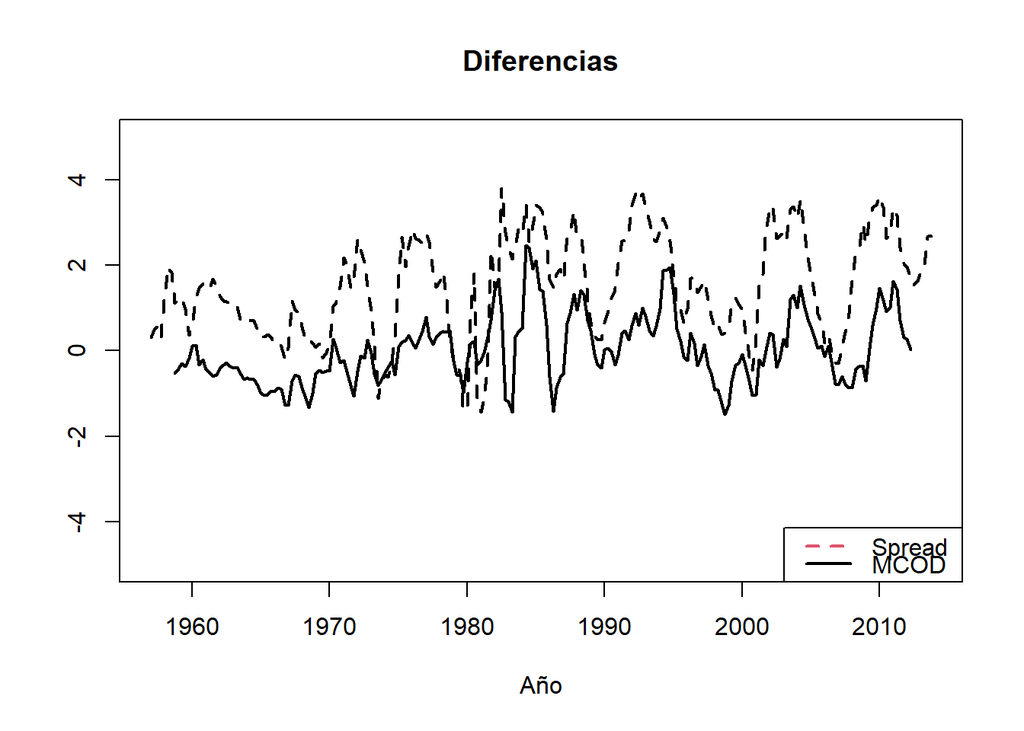

```r
x11()
plot(merge(as.zoo(TB10YS-TB3MS), as.zoo(residuals_FS_MCOD6)),
     plot.type = "single",
     lty = c(2, 1),
     lwd = 2,
     ylim = c(-5, 5),
     xlab = "Año",
     ylab = " ",
     main = "Diferencias")

legend("bottomright",
       legend = c("Spread","MCOD"),
       col = c(2,1),
       lwd = c(2, 2, 2),
       lty = c(2, 1, 1))
```

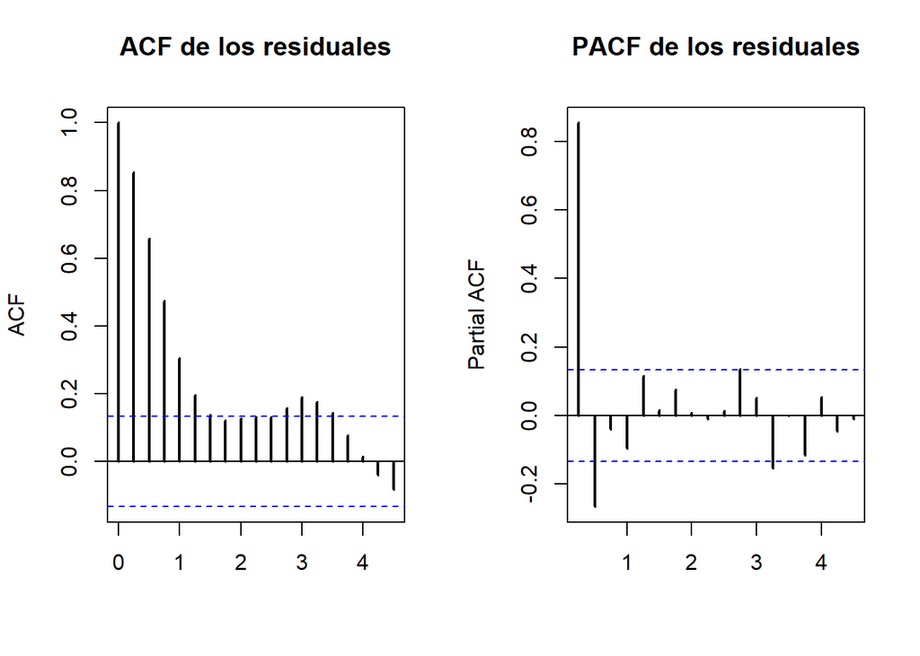

```r
lags = 18
par(mfrow=c(1,2))
acf(residuals_FS_MCOD6, lag.max=lags, plot=T , lwd=2 , xlab='', main='ACF de los residuales')
pacf(residuals_FS_MCOD6, lag.max=lags, plot=T, lwd=2, xlab='', main='PACF de los residuales')
```

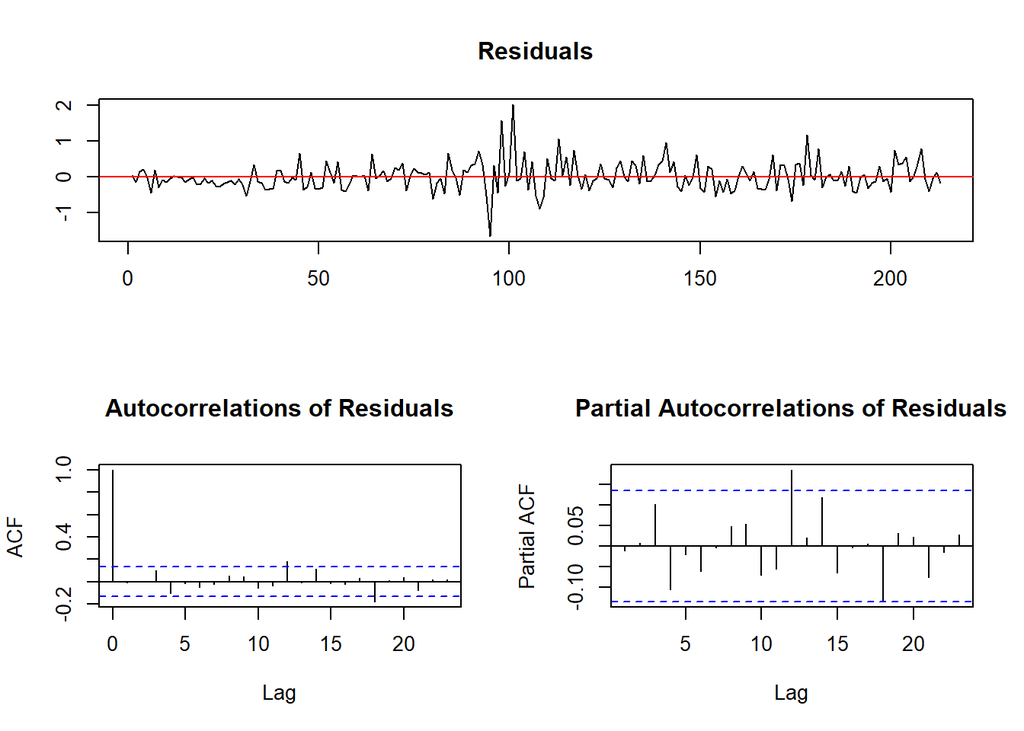

```r
#Hacemos la prueba ADF sobre los residuales del modelo MCOD
adf10 = ur.df(residuals(FS_MCOD6), lag=1, type = "none"); plot(adf10)
```

```r
summary(adf10) #Residuales estacionarios
```

```
##
## ###############################################
## # Augmented Dickey-Fuller Test Unit Root Test #
## ###############################################
##
## Test regression none
##
##
## Call:
## lm(formula = z.diff ~ z.lag.1 - 1 + z.diff.lag)
##
## Residuals:
##      Min       1Q   Median       3Q      Max
## -1.66841 -0.24745 -0.04813  0.18229  2.00989
##
## Coefficients:
##            Estimate Std. Error t value Pr(>|t|)
## z.lag.1    -0.18398    0.03566  -5.159 5.71e-07 ***
## z.diff.lag  0.26790    0.06631   4.040 7.48e-05 ***
## ---
## Signif. codes:  0 '***' 0.001 '**' 0.01 '*' 0.05 '.' 0.1 ' ' 1
##
## Residual standard error: 0.3994 on 211 degrees of freedom
## Multiple R-squared:  0.1396, Adjusted R-squared:  0.1315
## F-statistic: 17.12 on 2 and 211 DF,  p-value: 1.287e-07
##
##
## Value of test-statistic is: -5.1592
##
## Critical values for test statistics:
##       1pct  5pct 10pct
## tau1 -2.58 -1.95 -1.62
```

NOTA: Casi siempre los residuales en un modelo MCOD presentará autocorrelación debido a que no se incluyen rezagos de la variable dependiente, de manera que en esos casos es recomendable utilizar errores robustos tipo HAC.

En MCOD se incluyen adelantos y rezagos de la variable independiente, pero no de la variable dependiente, por lo que es usual que estos modelos presenten autocorrelación y sea necesario hacer la inferencia estadísticas con errores robustos HAC

### 3.2 Estimación del modelo de corrección de errores

En modelo de corrección de errores se estiman dos ecuaciones, cada una utilizando como variable dependiente una serie diferente de las dos series que están cointegradas (una serie diferente por cada ecuación diferente)

El término de corrección de error en el modelo es:

L(TB10YS - parametro_cointegración * TB3MS, 1) que es el término que recoge la relación de largo plazo entre TB10YS y TB3MS. Los coeficientes que acompañan al término de corrección de error en las dos ecuaciones del modelo se les conoce como coeficientes de velocidad de ajuste en la medida de que miden la velocidad en la que las variables se ajustan a su “atractor” o equilibrio de largo plazo cuando presentan desviaciones de este.

Para entender más a fondo el modelo de corrección de error revisar: los capítulos 6.4 y 6.5 del Enders

#### 3.2.1 Modelo de corrección de errores usando el parámetro de cointegración estimado por MCO

```r
# Parámetro/vector de cointegración que se obtuvó empleando MCO
parametro_cointegración_MCO = coint_param_MCO

VEC_EQ1 <- dynlm(d(TB10YS) ~  L(TB10YS - parametro_cointegración_MCO * TB3MS,1) + L(d(TB3MS), 0:3) + L(d(TB10YS), 1:3));summary(VEC_EQ1) #El parámetro de velocidad de ajuste alpha tiene el signo esperado
```

```
##
## Time series regression with "ts" data:
## Start = 1958(1), End = 2013(4)
##
## Call:
## dynlm(formula = d(TB10YS) ~ L(TB10YS - parametro_cointegración_MCO *
##     TB3MS, 1) + L(d(TB3MS), 0:3) + L(d(TB10YS), 1:3))
##
## Residuals:
##      Min       1Q   Median       3Q      Max
## -1.66962 -0.19775 -0.04191  0.14532  1.20485
##
## Coefficients:
##                                                     Estimate Std. Error t value
## (Intercept)                                         0.262136   0.061215   4.282
## L(TB10YS - parametro_cointegración_MCO * TB3MS, 1) -0.112113   0.024486  -4.579
## L(d(TB3MS), 0:3)0                                   0.426407   0.034699  12.289
## L(d(TB3MS), 0:3)1                                  -0.118259   0.046064  -2.567
## L(d(TB3MS), 0:3)2                                   0.008069   0.044502   0.181
## L(d(TB3MS), 0:3)3                                  -0.044153   0.044654  -0.989
## L(d(TB10YS), 1:3)1                                  0.196876   0.065230   3.018
## L(d(TB10YS), 1:3)2                                  0.006109   0.067039   0.091
## L(d(TB10YS), 1:3)3                                  0.032871   0.065795   0.500
##                                                    Pr(>|t|)
## (Intercept)                                        2.79e-05 ***
## L(TB10YS - parametro_cointegración_MCO * TB3MS, 1) 7.92e-06 ***
## L(d(TB3MS), 0:3)0                                   < 2e-16 ***
## L(d(TB3MS), 0:3)1                                   0.01093 *
## L(d(TB3MS), 0:3)2                                   0.85628
## L(d(TB3MS), 0:3)3                                   0.32389
## L(d(TB10YS), 1:3)1                                  0.00285 **
## L(d(TB10YS), 1:3)2                                  0.92748
## L(d(TB10YS), 1:3)3                                  0.61787
## ---
## Signif. codes:  0 '***' 0.001 '**' 0.01 '*' 0.05 '.' 0.1 ' ' 1
##
## Residual standard error: 0.3473 on 215 degrees of freedom
## Multiple R-squared:  0.4914, Adjusted R-squared:  0.4725
## F-statistic: 25.96 on 8 and 215 DF,  p-value: < 2.2e-16
```

```r
stargazer(VEC_EQ1, type = "text")
```

```
##
## ==============================================================================
##                                                        Dependent variable:
##                                                    ---------------------------
##                                                             d(TB10YS)
## ------------------------------------------------------------------------------
## L(TB10YS - parametro_cointegración_MCO * TB3MS, 1)          -0.112***
##                                                              (0.024)
##
## L(d(TB3MS), 0:3)0                                           0.426***
##                                                              (0.035)
##
## L(d(TB3MS), 0:3)1                                           -0.118**
##                                                              (0.046)
##
## L(d(TB3MS), 0:3)2                                             0.008
##                                                              (0.045)
##
## L(d(TB3MS), 0:3)3                                            -0.044
##                                                              (0.045)
##
## L(d(TB10YS), 1:3)1                                          0.197***
##                                                              (0.065)
##
## L(d(TB10YS), 1:3)2                                            0.006
##                                                              (0.067)
##
## L(d(TB10YS), 1:3)3                                            0.033
##                                                              (0.066)
##
## Constant                                                    0.262***
##                                                              (0.061)
##
## ------------------------------------------------------------------------------
## Observations                                                   224
## R2                                                            0.491
## Adjusted R2                                                   0.472
## Residual Std. Error                                     0.347 (df = 215)
## F Statistic                                          25.964*** (df = 8; 215)
## ==============================================================================
## Note:                                              *p<0.1; **p<0.05; ***p<0.01
```

```r
VEC_EQ2 <- dynlm(d(TB3MS) ~  L(TB10YS - parametro_cointegración_MCO * TB3MS,1)+ L(d(TB3MS), 1:3) + L(d(TB10YS), 0:3));summary(VEC_EQ2) #El parámetro de velocidad de ajuste alpha tiene el signo esperado
```

```
##
## Time series regression with "ts" data:
## Start = 1958(1), End = 2013(4)
##
## Call:
## dynlm(formula = d(TB3MS) ~ L(TB10YS - parametro_cointegración_MCO *
##     TB3MS, 1) + L(d(TB3MS), 1:3) + L(d(TB10YS), 0:3))
##
## Residuals:
##      Min       1Q   Median       3Q      Max
## -2.44717 -0.22388  0.05126  0.28208  2.06867
##
## Coefficients:
##                                                    Estimate Std. Error t value
## (Intercept)                                        -0.34320    0.09317  -3.684
## L(TB10YS - parametro_cointegración_MCO * TB3MS, 1)  0.14460    0.03736   3.870
## L(d(TB3MS), 1:3)1                                   0.32130    0.06695   4.799
## L(d(TB3MS), 1:3)2                                  -0.14287    0.06633  -2.154
## L(d(TB3MS), 1:3)3                                   0.19029    0.06616   2.876
## L(d(TB10YS), 0:3)0                                  0.96760    0.07874  12.289
## L(d(TB10YS), 0:3)1                                 -0.14239    0.09985  -1.426
## L(d(TB10YS), 0:3)2                                 -0.12047    0.10065  -1.197
## L(d(TB10YS), 0:3)3                                  0.02710    0.09915   0.273
##                                                    Pr(>|t|)
## (Intercept)                                        0.000291 ***
## L(TB10YS - parametro_cointegración_MCO * TB3MS, 1) 0.000144 ***
## L(d(TB3MS), 1:3)1                                  2.98e-06 ***
## L(d(TB3MS), 1:3)2                                  0.032354 *
## L(d(TB3MS), 1:3)3                                  0.004429 **
## L(d(TB10YS), 0:3)0                                  < 2e-16 ***
## L(d(TB10YS), 0:3)1                                 0.155318
## L(d(TB10YS), 0:3)2                                 0.232650
## L(d(TB10YS), 0:3)3                                 0.784846
## ---
## Signif. codes:  0 '***' 0.001 '**' 0.01 '*' 0.05 '.' 0.1 ' ' 1
##
## Residual standard error: 0.5232 on 215 degrees of freedom
## Multiple R-squared:  0.5248, Adjusted R-squared:  0.5071
## F-statistic: 29.68 on 8 and 215 DF,  p-value: < 2.2e-16
```

```r
stargazer(VEC_EQ2, type = "text")
```

```
##
## ==============================================================================
##                                                        Dependent variable:
##                                                    ---------------------------
##                                                             d(TB3MS)
## ------------------------------------------------------------------------------
## L(TB10YS - parametro_cointegración_MCO * TB3MS, 1)          0.145***
##                                                              (0.037)
##
## L(d(TB3MS), 1:3)1                                           0.321***
##                                                              (0.067)
##
## L(d(TB3MS), 1:3)2                                           -0.143**
##                                                              (0.066)
##
## L(d(TB3MS), 1:3)3                                           0.190***
##                                                              (0.066)
##
## L(d(TB10YS), 0:3)0                                          0.968***
##                                                              (0.079)
##
## L(d(TB10YS), 0:3)1                                           -0.142
##                                                              (0.100)
##
## L(d(TB10YS), 0:3)2                                           -0.120
##                                                              (0.101)
##
## L(d(TB10YS), 0:3)3                                            0.027
##                                                              (0.099)
##
## Constant                                                    -0.343***
##                                                              (0.093)
##
## ------------------------------------------------------------------------------
## Observations                                                   224
## R2                                                            0.525
## Adjusted R2                                                   0.507
## Residual Std. Error                                     0.523 (df = 215)
## F Statistic                                          29.676*** (df = 8; 215)
## ==============================================================================
## Note:                                              *p<0.1; **p<0.05; ***p<0.01
```

#### 3.2.2 Modelo de corrección de errores usando el parámetro de cointegración estimado por MCOD

```r
# Parámetro/vector de cointegración que se obtuvó empleando MCOD
parametro_cointegración_MCOD = coint_param_MCOD

VEC_EQ3 <- dynlm(d(TB10YS) ~  L(TB10YS - parametro_cointegración_MCOD * TB3MS, 1) + L(d(TB3MS), 0:3) + L(d(TB10YS), 1:3));summary(VEC_EQ3) #El parámetro de velocidad de ajuste alpha tiene el signo esperado
```

```
##
## Time series regression with "ts" data:
## Start = 1958(1), End = 2013(4)
##
## Call:
## dynlm(formula = d(TB10YS) ~ L(TB10YS - parametro_cointegración_MCOD *
##     TB3MS, 1) + L(d(TB3MS), 0:3) + L(d(TB10YS), 1:3))
##
## Residuals:
##      Min       1Q   Median       3Q      Max
## -1.74150 -0.18127 -0.03765  0.14095  1.16588
##
## Coefficients:
##                                                      Estimate Std. Error
## (Intercept)                                          0.197577   0.046434
## L(TB10YS - parametro_cointegración_MCOD * TB3MS, 1) -0.114901   0.023761
## L(d(TB3MS), 0:3)0                                    0.436226   0.034738
## L(d(TB3MS), 0:3)1                                   -0.127855   0.046226
## L(d(TB3MS), 0:3)2                                    0.006031   0.044268
## L(d(TB3MS), 0:3)3                                   -0.051106   0.044667
## L(d(TB10YS), 1:3)1                                   0.188869   0.064789
## L(d(TB10YS), 1:3)2                                  -0.001499   0.066530
## L(d(TB10YS), 1:3)3                                   0.020656   0.065265
##                                                     t value Pr(>|t|)
## (Intercept)                                           4.255 3.12e-05 ***
## L(TB10YS - parametro_cointegración_MCOD * TB3MS, 1)  -4.836 2.53e-06 ***
## L(d(TB3MS), 0:3)0                                    12.558  < 2e-16 ***
## L(d(TB3MS), 0:3)1                                    -2.766  0.00617 **
## L(d(TB3MS), 0:3)2                                     0.136  0.89175
## L(d(TB3MS), 0:3)3                                    -1.144  0.25383
## L(d(TB10YS), 1:3)1                                    2.915  0.00393 **
## L(d(TB10YS), 1:3)2                                   -0.023  0.98204
## L(d(TB10YS), 1:3)3                                    0.316  0.75193
## ---
## Signif. codes:  0 '***' 0.001 '**' 0.01 '*' 0.05 '.' 0.1 ' ' 1
##
## Residual standard error: 0.3456 on 215 degrees of freedom
## Multiple R-squared:  0.4965, Adjusted R-squared:  0.4778
## F-statistic: 26.51 on 8 and 215 DF,  p-value: < 2.2e-16
```

```r
stargazer(VEC_EQ3, type = "text")
```

```
##
## ===============================================================================
##                                                         Dependent variable:
##                                                     ---------------------------
##                                                              d(TB10YS)
## -------------------------------------------------------------------------------
## L(TB10YS - parametro_cointegración_MCOD * TB3MS, 1)          -0.115***
##                                                               (0.024)
##
## L(d(TB3MS), 0:3)0                                            0.436***
##                                                               (0.035)
##
## L(d(TB3MS), 0:3)1                                            -0.128***
##                                                               (0.046)
##
## L(d(TB3MS), 0:3)2                                              0.006
##                                                               (0.044)
##
## L(d(TB3MS), 0:3)3                                             -0.051
##                                                               (0.045)
##
## L(d(TB10YS), 1:3)1                                           0.189***
##                                                               (0.065)
##
## L(d(TB10YS), 1:3)2                                            -0.001
##                                                               (0.067)
##
## L(d(TB10YS), 1:3)3                                             0.021
##                                                               (0.065)
##
## Constant                                                     0.198***
##                                                               (0.046)
##
## -------------------------------------------------------------------------------
## Observations                                                    224
## R2                                                             0.497
## Adjusted R2                                                    0.478
## Residual Std. Error                                      0.346 (df = 215)
## F Statistic                                           26.506*** (df = 8; 215)
## ===============================================================================
## Note:                                               *p<0.1; **p<0.05; ***p<0.01
```

```r
VEC_EQ4 <- dynlm(d(TB3MS) ~  L(TB10YS - parametro_cointegración_MCOD * TB3MS, 1)+ L(d(TB3MS), 1:3) + L(d(TB10YS), 0:3));summary(VEC_EQ4) #El parámetro de velocidad de ajuste alpha tiene el signo esperado
```

```
##
## Time series regression with "ts" data:
## Start = 1958(1), End = 2013(4)
##
## Call:
## dynlm(formula = d(TB3MS) ~ L(TB10YS - parametro_cointegración_MCOD *
##     TB3MS, 1) + L(d(TB3MS), 1:3) + L(d(TB10YS), 0:3))
##
## Residuals:
##      Min       1Q   Median       3Q      Max
## -2.27329 -0.23548  0.04755  0.29052  2.16456
##
## Coefficients:
##                                                     Estimate Std. Error t value
## (Intercept)                                         -0.29169    0.06930  -4.209
## L(TB10YS - parametro_cointegración_MCOD * TB3MS, 1)  0.16704    0.03553   4.702
## L(d(TB3MS), 1:3)1                                    0.33922    0.06622   5.122
## L(d(TB3MS), 1:3)2                                   -0.12842    0.06543  -1.963
## L(d(TB3MS), 1:3)3                                    0.20567    0.06532   3.149
## L(d(TB10YS), 0:3)0                                   0.96997    0.07724  12.558
## L(d(TB10YS), 0:3)1                                  -0.13638    0.09806  -1.391
## L(d(TB10YS), 0:3)2                                  -0.11136    0.09892  -1.126
## L(d(TB10YS), 0:3)3                                   0.03832    0.09731   0.394
##                                                     Pr(>|t|)
## (Intercept)                                         3.76e-05 ***
## L(TB10YS - parametro_cointegración_MCOD * TB3MS, 1) 4.60e-06 ***
## L(d(TB3MS), 1:3)1                                   6.69e-07 ***
## L(d(TB3MS), 1:3)2                                    0.05096 .
## L(d(TB3MS), 1:3)3                                    0.00187 **
## L(d(TB10YS), 0:3)0                                   < 2e-16 ***
## L(d(TB10YS), 0:3)1                                   0.16573
## L(d(TB10YS), 0:3)2                                   0.26149
## L(d(TB10YS), 0:3)3                                   0.69411
## ---
## Signif. codes:  0 '***' 0.001 '**' 0.01 '*' 0.05 '.' 0.1 ' ' 1
##
## Residual standard error: 0.5153 on 215 degrees of freedom
## Multiple R-squared:  0.5391, Adjusted R-squared:  0.5219
## F-statistic: 31.43 on 8 and 215 DF,  p-value: < 2.2e-16
```

```r
stargazer(VEC_EQ4, type = "text")
```

```
##
## ===============================================================================
##                                                         Dependent variable:
##                                                     ---------------------------
##                                                              d(TB3MS)
## -------------------------------------------------------------------------------
## L(TB10YS - parametro_cointegración_MCOD * TB3MS, 1)          0.167***
##                                                               (0.036)
##
## L(d(TB3MS), 1:3)1                                            0.339***
##                                                               (0.066)
##
## L(d(TB3MS), 1:3)2                                             -0.128*
##                                                               (0.065)
##
## L(d(TB3MS), 1:3)3                                            0.206***
##                                                               (0.065)
##
## L(d(TB10YS), 0:3)0                                           0.970***
##                                                               (0.077)
##
## L(d(TB10YS), 0:3)1                                            -0.136
##                                                               (0.098)
##
## L(d(TB10YS), 0:3)2                                            -0.111
##                                                               (0.099)
##
## L(d(TB10YS), 0:3)3                                             0.038
##                                                               (0.097)
##
## Constant                                                     -0.292***
##                                                               (0.069)
##
## -------------------------------------------------------------------------------
## Observations                                                    224
## R2                                                             0.539
## Adjusted R2                                                    0.522
## Residual Std. Error                                      0.515 (df = 215)
## F Statistic                                           31.429*** (df = 8; 215)
## ===============================================================================
## Note:                                               *p<0.1; **p<0.05; ***p<0.01
```

## PASO 4: Validación de supuestos del modelo de corrección de errores —-

En este caso, vamos a hacer la validación de supuestos del modelo de corrección de errores donde reemplazamos como coeficiente de cointegración el obtenido por MCOD, es decir, parametro_cointegración_MCOD

```r
#Cálculo de los residuales del modelo:
residuales_VEC_EQ3 = residuals(VEC_EQ3)
residuales_VEC_EQ4 = residuals(VEC_EQ4)
```

Analizamos que los residuales sean estacionarios:

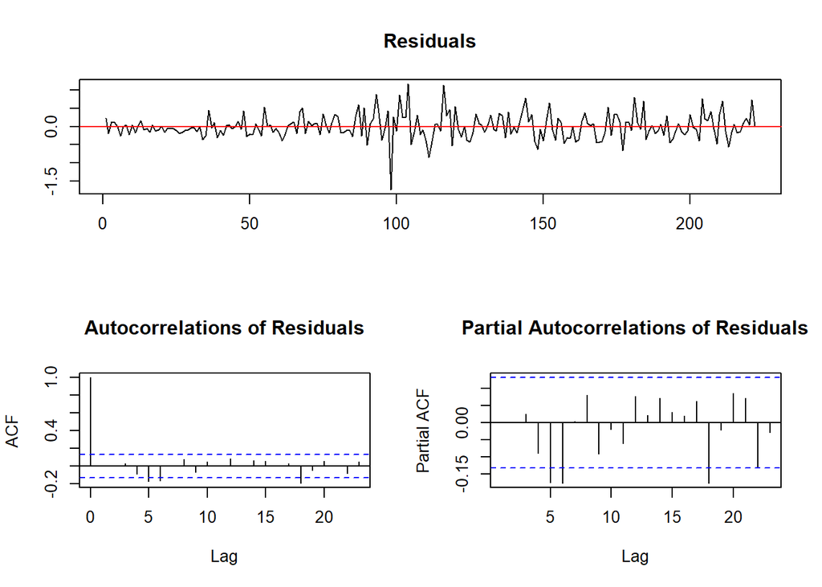

```r
# Ecuación VEC_EQ3
adf_VEC_EQ3 = ur.df(residuales_VEC_EQ3, lag=1, type = "none"); plot(adf_VEC_EQ3)
```

```r
summary(adf_VEC_EQ3) # Residuales estacionarios.
```

```
##
## ###############################################
## # Augmented Dickey-Fuller Test Unit Root Test #
## ###############################################
##
## Test regression none
##
##
## Call:
## lm(formula = z.diff ~ z.lag.1 - 1 + z.diff.lag)
##
## Residuals:
##      Min       1Q   Median       3Q      Max
## -1.74204 -0.18850 -0.04285  0.13903  1.16867
##
## Coefficients:
##            Estimate Std. Error t value Pr(>|t|)
## z.lag.1    -1.01156    0.09583 -10.556   <2e-16 ***
## z.diff.lag  0.01134    0.06811   0.166    0.868
## ---
## Signif. codes:  0 '***' 0.001 '**' 0.01 '*' 0.05 '.' 0.1 ' ' 1
##
## Residual standard error: 0.3415 on 220 degrees of freedom
## Multiple R-squared:  0.5003, Adjusted R-squared:  0.4957
## F-statistic: 110.1 on 2 and 220 DF,  p-value: < 2.2e-16
##
##
## Value of test-statistic is: -10.5561
##
## Critical values for test statistics:
##       1pct  5pct 10pct
## tau1 -2.58 -1.95 -1.62
```

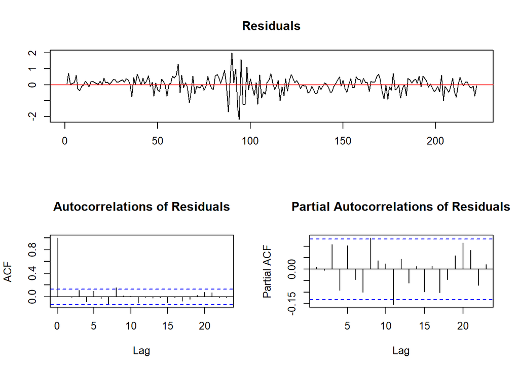

```r
# Ecuación VEC_EQ4
adf_VEC_EQ4 = ur.df(residuales_VEC_EQ4, lag=1, type = "none"); plot(adf_VEC_EQ4)
```

```r
summary(adf_VEC_EQ4) #Residuales estacionarios.
```

```
##
## ###############################################
## # Augmented Dickey-Fuller Test Unit Root Test #
## ###############################################
##
## Test regression none
##
##
## Call:
## lm(formula = z.diff ~ z.lag.1 - 1 + z.diff.lag)
##
## Residuals:
##      Min       1Q   Median       3Q      Max
## -2.18584 -0.22892  0.05583  0.30437  2.00264
##
## Coefficients:
##            Estimate Std. Error t value Pr(>|t|)
## z.lag.1    -1.07983    0.09429 -11.452   <2e-16 ***
## z.diff.lag  0.09039    0.06706   1.348    0.179
## ---
## Signif. codes:  0 '***' 0.001 '**' 0.01 '*' 0.05 '.' 0.1 ' ' 1
##
## Residual standard error: 0.5045 on 220 degrees of freedom
## Multiple R-squared:  0.4997, Adjusted R-squared:  0.4952
## F-statistic: 109.9 on 2 and 220 DF,  p-value: < 2.2e-16
##
##
## Value of test-statistic is: -11.4522
##
## Critical values for test statistics:
##       1pct  5pct 10pct
## tau1 -2.58 -1.95 -1.62
```

De la preuba de ADF aplicado a estos residuales hay que tener cuidado en utilizar los valores criticos correctos dado que al incluir el terimino de correccion de error se están incluyendo estimaciones de una primera etapa lo que hace que los valores criticos para una ADF aplicada a los residuales del modelo de corrección de errores pueden cambiar. Los valores criticos para usar son los mismos que se usan para la prueba de cointegracion de Engle-Granger y están en el manual suplementario del Enders (Tabla C). No obstante, dicho test no es para probar que los residuales son ruido blanco sino que son estacionarios en media, lo cual es una consecuencia de que haya cointegración.

Test para probar que los residuales son ruido blanco

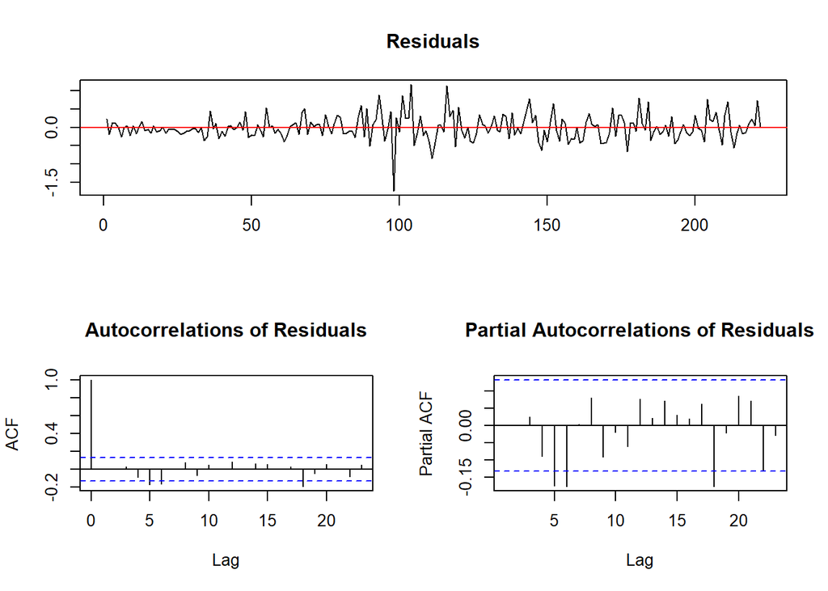

```r
# Ecuación VEC_EQ3
adf_VEC_EQ3 = ur.df(residuales_VEC_EQ3, lag=1, type = "none"); plot(adf_VEC_EQ3)
```

```r
summary(adf_VEC_EQ3) # Residuales estacionarios.
```

```
##
## ###############################################
## # Augmented Dickey-Fuller Test Unit Root Test #
## ###############################################
##
## Test regression none
##
##
## Call:
## lm(formula = z.diff ~ z.lag.1 - 1 + z.diff.lag)
##
## Residuals:
##      Min       1Q   Median       3Q      Max
## -1.74204 -0.18850 -0.04285  0.13903  1.16867
##
## Coefficients:
##            Estimate Std. Error t value Pr(>|t|)
## z.lag.1    -1.01156    0.09583 -10.556   <2e-16 ***
## z.diff.lag  0.01134    0.06811   0.166    0.868
## ---
## Signif. codes:  0 '***' 0.001 '**' 0.01 '*' 0.05 '.' 0.1 ' ' 1
##
## Residual standard error: 0.3415 on 220 degrees of freedom
## Multiple R-squared:  0.5003, Adjusted R-squared:  0.4957
## F-statistic: 110.1 on 2 and 220 DF,  p-value: < 2.2e-16
##
##
## Value of test-statistic is: -10.5561
##
## Critical values for test statistics:
##       1pct  5pct 10pct
## tau1 -2.58 -1.95 -1.62
```

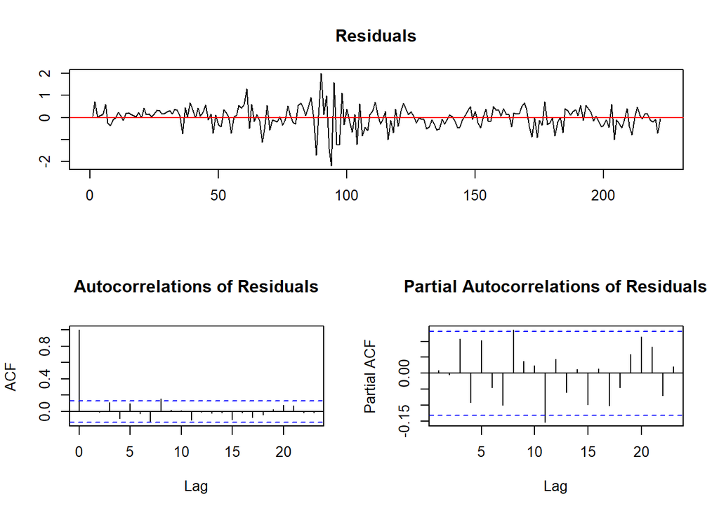

```r
# Ecuación VEC_EQ4
adf_VEC_EQ4 = ur.df(residuales_VEC_EQ4, lag=1, type = "none"); plot(adf_VEC_EQ4)
```

```r
summary(adf_VEC_EQ4) #Residuales estacionarios.
```

```
##
## ###############################################
## # Augmented Dickey-Fuller Test Unit Root Test #
## ###############################################
##
## Test regression none
##
##
## Call:
## lm(formula = z.diff ~ z.lag.1 - 1 + z.diff.lag)
##
## Residuals:
##      Min       1Q   Median       3Q      Max
## -2.18584 -0.22892  0.05583  0.30437  2.00264
##
## Coefficients:
##            Estimate Std. Error t value Pr(>|t|)
## z.lag.1    -1.07983    0.09429 -11.452   <2e-16 ***
## z.diff.lag  0.09039    0.06706   1.348    0.179
## ---
## Signif. codes:  0 '***' 0.001 '**' 0.01 '*' 0.05 '.' 0.1 ' ' 1
##
## Residual standard error: 0.5045 on 220 degrees of freedom
## Multiple R-squared:  0.4997, Adjusted R-squared:  0.4952
## F-statistic: 109.9 on 2 and 220 DF,  p-value: < 2.2e-16
##
##
## Value of test-statistic is: -11.4522
##
## Critical values for test statistics:
##       1pct  5pct 10pct
## tau1 -2.58 -1.95 -1.62
```

```r
# Selección del número de lags para la prueba
length(residuales_VEC_EQ3)/4 # aproximdamente 60
```

```
## [1] 56
```

```r
# Test Box-Pierce para autocorrelación en los residuales
Box.test(residuales_VEC_EQ3,lag=60, type = c("Box-Pierce")) #No rechazo H0, se cumple el supuesto.
```

```
##
##  Box-Pierce test
##
## data:  residuales_VEC_EQ3
## X-squared = 74.251, df = 60, p-value = 0.102
```

```r
Box.test(residuales_VEC_EQ3,type='Box-Pierce',lag=20) #No rechazo H0, se cumple el supuesto.
```

```
##
##  Box-Pierce test
##
## data:  residuales_VEC_EQ3
## X-squared = 30.916, df = 20, p-value = 0.05632
```

```r
Box.test(residuales_VEC_EQ3,type='Box-Pierce',lag=30) #No rechazo H0,  se cumple el supuesto.
```

```
##
##  Box-Pierce test
##
## data:  residuales_VEC_EQ3
## X-squared = 42.516, df = 30, p-value = 0.0646
```

```r
Box.test(residuales_VEC_EQ4,lag=60, type = c("Ljung-Box")) #NO rechazo H0, se cumple el supuesto.
```

```
##
##  Box-Ljung test
##
## data:  residuales_VEC_EQ4
## X-squared = 66.184, df = 60, p-value = 0.272
```

```r
Box.test(residuales_VEC_EQ4,type='Ljung-Box',lag=20) #NO rechazo H0, se cumple el supuesto.
```

```
##
##  Box-Ljung test
##
## data:  residuales_VEC_EQ4
## X-squared = 26.178, df = 20, p-value = 0.16
```

```r
Box.test(residuales_VEC_EQ4,type='Ljung-Box',lag=30) #NO rechazo H0,  se cumple el supuesto.
```

```
##
##  Box-Ljung test
##
## data:  residuales_VEC_EQ4
## X-squared = 35.229, df = 30, p-value = 0.2344
```

En tanto los residuales no están autocorrelacionados en ninguna ecuación, deberían validar los demás supuestos.

A diferencia de MCOD que solo tiene incorporados rezagos de la variable independiente, la inclusión de rezgos de la variable dependiente en la ecaución, hace que el modelo de corrección de errores sí capture las estructuras de correlación de carácter autorregresivo que allí no se incorporan, y que ademas pueden estar presentes en la serie.

Nota: Es importante tener en cuenta que:

1. MCOD: Está diseñado para estimar el vector/parámetro de cointegración. El proposito principal del modelo MCOD es calcular ese parámetro de cointegración que luego va a ser utilizado/empleado en el modelo de correción de errores que se estima posteriormente, luego de conocer el valor del parámetro de cointegración. Por tanto, MCOD se utiliza para saber cuál es el valor del parámetro de cointegración, si ese parámetro es estadísticamente significativo, y empleando un test de cointegración de Engle-Granger establecer si las series están cointegradas.
2. Modelo de corrección de errores: Se estiman luego de haber estimado el parámetro de cointegración utilizando MCOD y haber establecido de que en efecto las series están cointegradas mediante un test de cointegración de Engle-Granger. Nos interesan, en particular los coeficientes que acompañana el término de error en las ecuaciones del modelo en la medida de que dan información sobre la velocidad en la que se ajustan las variables luego de desviaciones a su atractor o equilibrio de largo plazo

# B. PPA

Ahora haremos un ejericio del libro de Enders para probar la PPA R=N*(P*/P)-> r= e + log(P*) - log(P)

JAPANCPI is the Japanese price level and JAPANEX is the bilateral Japanese/U.S. exchange rate.

The starting date for all variables is January 1974 while the availability of the variables is such that most end near the end of 2012. The price indices have been normalized to equal 100 in January 1973

```r
PPA <- read_excel(file.choose())
attach(PPA)
View(PPA)

e = ts(log(JAPANEX), start=c(1974,1), frequency=12)
lp.j = ts(log(JAPANCPI), start=c(1974,1), frequency=12)
lp.u = ts(log(USCPI), start=c(1974,1), frequency=12)
```

METODOLOGÍA ENGLE & GRANGER.

Paso 1: Aplicaremos la prueba ADF y KPSS sobre cada una de las series.

Prueba sobre el logaritmo de la tasa de cambio nominal

Primero vamos a hacer una prueba de ADF con tendencia e intercepto.Los valores críticos de la prueba son sensibles a la inclusión de términos determinísticos, de manera que hay que determinar si la serie tiene tendencia y/o intercepto.

```r
adf11= ur.df(e, lags=9, type = "trend")
summary(adf11)
```

```
##
## ###############################################
## # Augmented Dickey-Fuller Test Unit Root Test #
## ###############################################
##
## Test regression trend
##
##
## Call:
## lm(formula = z.diff ~ z.lag.1 + 1 + tt + z.diff.lag)
##
## Residuals:
##       Min        1Q    Median        3Q       Max
## -0.092211 -0.015329  0.001745  0.018237  0.071597
##
## Coefficients:
##               Estimate Std. Error t value Pr(>|t|)
## (Intercept)  9.687e-02  4.176e-02   2.320   0.0208 *
## z.lag.1     -1.814e-02  7.506e-03  -2.416   0.0161 *
## tt          -3.651e-05  2.119e-05  -1.723   0.0857 .
## z.diff.lag1  3.228e-01  4.708e-02   6.856 2.37e-11 ***
## z.diff.lag2 -2.905e-02  4.931e-02  -0.589   0.5561
## z.diff.lag3  7.532e-02  4.937e-02   1.526   0.1278
## z.diff.lag4  2.032e-02  4.942e-02   0.411   0.6812
## z.diff.lag5 -7.551e-02  4.939e-02  -1.529   0.1270
## z.diff.lag6 -5.962e-02  4.969e-02  -1.200   0.2309
## z.diff.lag7 -2.120e-03  4.991e-02  -0.042   0.9661
## z.diff.lag8  1.201e-01  4.992e-02   2.405   0.0166 *
## z.diff.lag9  5.169e-02  4.785e-02   1.080   0.2806
## ---
## Signif. codes:  0 '***' 0.001 '**' 0.01 '*' 0.05 '.' 0.1 ' ' 1
##
## Residual standard error: 0.02567 on 446 degrees of freedom
## Multiple R-squared:  0.1466, Adjusted R-squared:  0.1255
## F-statistic: 6.964 on 11 and 446 DF,  p-value: 6.636e-11
##
##
## Value of test-statistic is: -2.4162 2.8148 3.4796
##
## Critical values for test statistics:
##       1pct  5pct 10pct
## tau3 -3.98 -3.42 -3.13
## phi2  6.15  4.71  4.05
## phi3  8.34  6.30  5.36
```

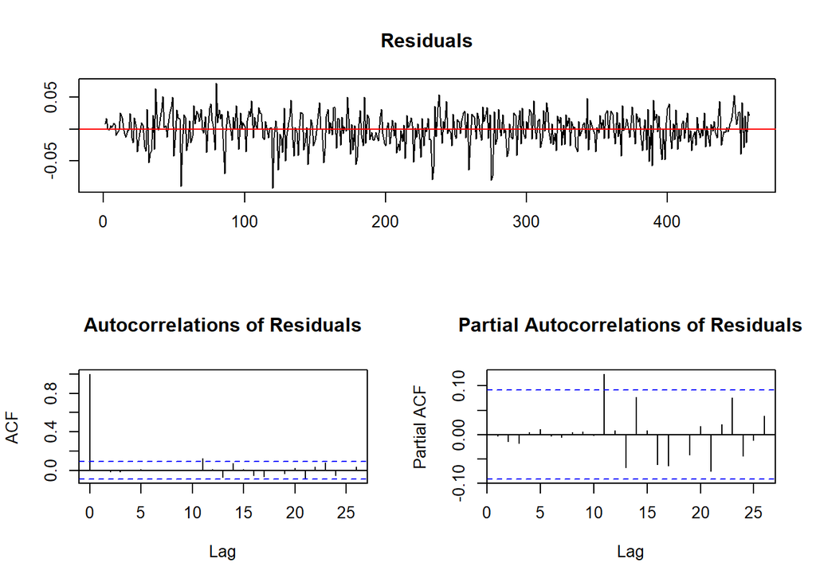

```r
plot(adf11)
```

El tau nos dice que la serie tiene al menos una raíz unitaria, mientras el phi3 nos dice que la tendencia no es significativa. Por lo tanto, vamos a mirar únicamente la prueba con intercepto.

```r
adf12= ur.df(e, lags=9, type = "drift")
summary(adf12)
```

```
##
## ###############################################
## # Augmented Dickey-Fuller Test Unit Root Test #
## ###############################################
##
## Test regression drift
##
##
## Call:
## lm(formula = z.diff ~ z.lag.1 + 1 + z.diff.lag)
##
## Residuals:
##       Min        1Q    Median        3Q       Max
## -0.094576 -0.015400  0.001918  0.018762  0.071167
##
## Coefficients:
##              Estimate Std. Error t value Pr(>|t|)
## (Intercept)  0.030461   0.016075   1.895   0.0588 .
## z.lag.1     -0.006473   0.003247  -1.994   0.0468 *
## z.diff.lag1  0.317561   0.047087   6.744 4.77e-11 ***
## z.diff.lag2 -0.037180   0.049187  -0.756   0.4501
## z.diff.lag3  0.067244   0.049256   1.365   0.1729
## z.diff.lag4  0.012915   0.049343   0.262   0.7936
## z.diff.lag5 -0.082768   0.049319  -1.678   0.0940 .
## z.diff.lag6 -0.065600   0.049677  -1.321   0.1873
## z.diff.lag7 -0.009290   0.049843  -0.186   0.8522
## z.diff.lag8  0.114124   0.049913   2.286   0.0227 *
## z.diff.lag9  0.041903   0.047613   0.880   0.3793
## ---
## Signif. codes:  0 '***' 0.001 '**' 0.01 '*' 0.05 '.' 0.1 ' ' 1
##
## Residual standard error: 0.02573 on 447 degrees of freedom
## Multiple R-squared:  0.1409, Adjusted R-squared:  0.1217
## F-statistic: 7.331 on 10 and 447 DF,  p-value: 8.693e-11
##
##
## Value of test-statistic is: -1.9936 2.7267
##
## Critical values for test statistics:
##       1pct  5pct 10pct
## tau2 -3.44 -2.87 -2.57
## phi1  6.47  4.61  3.79
```

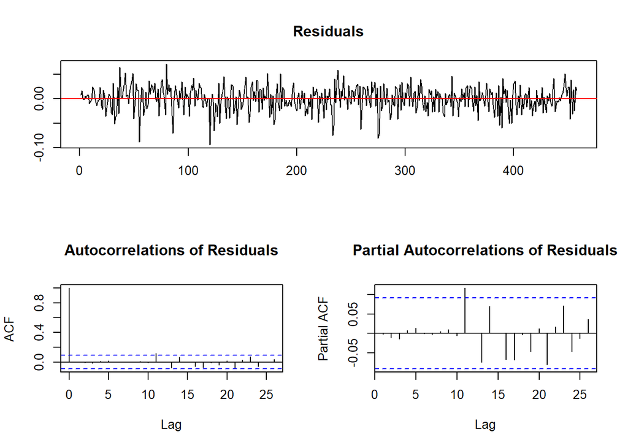

```r
plot(adf12)
```

```r
adf13=ur.df(e, lags=9, type = "none")
summary(adf13)
```

```
##
## ###############################################
## # Augmented Dickey-Fuller Test Unit Root Test #
## ###############################################
##
## Test regression none
##
##
## Call:
## lm(formula = z.diff ~ z.lag.1 - 1 + z.diff.lag)
##
## Residuals:
##       Min        1Q    Median        3Q       Max
## -0.097686 -0.014735  0.001866  0.018913  0.068217
##
## Coefficients:
##               Estimate Std. Error t value Pr(>|t|)
## z.lag.1     -0.0003386  0.0002488  -1.361   0.1742
## z.diff.lag1  0.3189785  0.0472168   6.756 4.43e-11 ***
## z.diff.lag2 -0.0388000  0.0493212  -0.787   0.4319
## z.diff.lag3  0.0661311  0.0493946   1.339   0.1813
## z.diff.lag4  0.0111338  0.0494765   0.225   0.8221
## z.diff.lag5 -0.0842831  0.0494550  -1.704   0.0890 .
## z.diff.lag6 -0.0666913  0.0498170  -1.339   0.1813
## z.diff.lag7 -0.0100004  0.0499850  -0.200   0.8415
## z.diff.lag8  0.1134684  0.0500557   2.267   0.0239 *
## z.diff.lag9  0.0397187  0.0477362   0.832   0.4058
## ---
## Signif. codes:  0 '***' 0.001 '**' 0.01 '*' 0.05 '.' 0.1 ' ' 1
##
## Residual standard error: 0.0258 on 448 degrees of freedom
## Multiple R-squared:  0.1403, Adjusted R-squared:  0.1211
## F-statistic:  7.31 on 10 and 448 DF,  p-value: 9.379e-11
##
##
## Value of test-statistic is: -1.3609
##
## Critical values for test statistics:
##       1pct  5pct 10pct
## tau1 -2.58 -1.95 -1.62
```

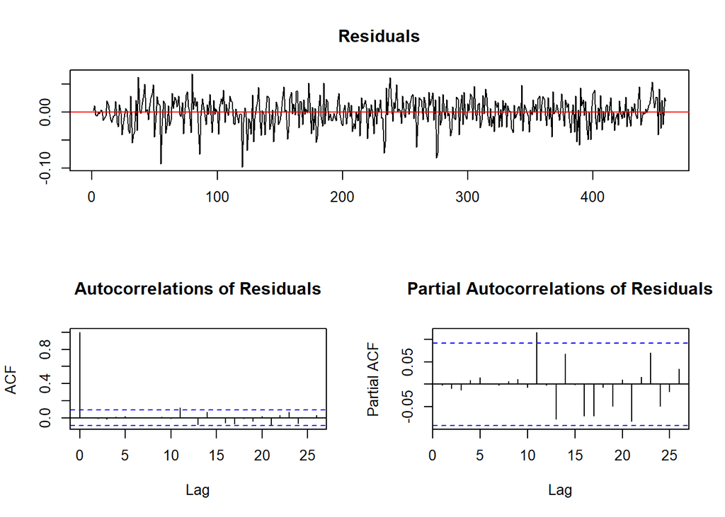

```r
plot(adf13)
```

Claramente se evidencia que la serie tiene al menos una raíz unitaria, en tanto no se rechaza la hipótesis nula. Noten la importancia de determinar si la serie tiene términos detemrminísticos, pues el valor calculado en cadaespecificación de la prueba cambió de forma importante.

Hacemos la prueba KPSS cuya hipótesis nula es que la serie es estacionaria, la cual es totalmente contraria a la ADF.

```r
kp3= ur.kpss(e, use.lag = 9, type = "mu") #el mu nos indica que es una prueba sin términos deterministicos.
summary(kp3)
```

```
##
## #######################
## # KPSS Unit Root Test #
## #######################
##
## Test is of type: mu with 9 lags.
##
## Value of test-statistic is: 3.9233
##
## Critical value for a significance level of:
##                 10pct  5pct 2.5pct  1pct
## critical values 0.347 0.463  0.574 0.739
```

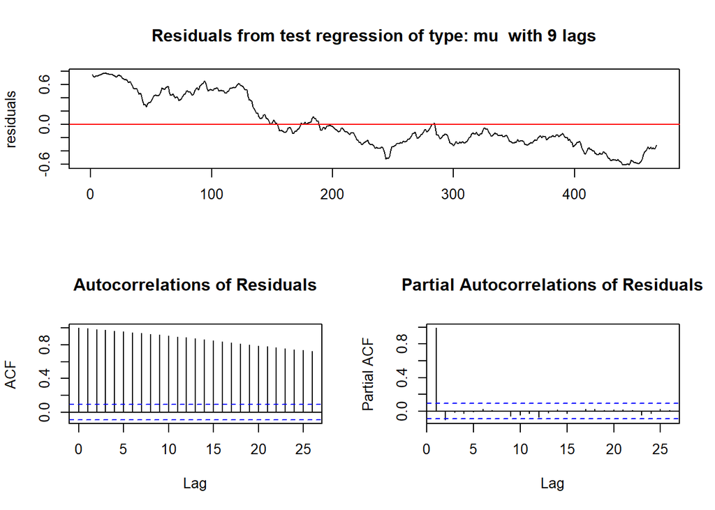

```r
plot(kp3)
```

Claramente rechazamos la hipótesis nula de estacionariedad, así que las serie no es estacionaria.

Prueba sobre el logaritmo del nivel internacional de precios

Primero vamos a hacer una prueba de ADF con tendencia e intercepto.Los valores críticos de la prueba son sensibles a la inclusión de términos determinísticos, de manera que hay que determinar si la serie tiene tendencia y/o intercepto.

```r
adf14= ur.df(lp.j, lags=8, type = "trend")
summary(adf14)
```

```
##
## ###############################################
## # Augmented Dickey-Fuller Test Unit Root Test #
## ###############################################
##
## Test regression trend
##
##
## Call:
## lm(formula = z.diff ~ z.lag.1 + 1 + tt + z.diff.lag)
##
## Residuals:
##        Min         1Q     Median         3Q        Max
## -0.0138621 -0.0024286  0.0000633  0.0021376  0.0194776
##
## Coefficients:
##               Estimate Std. Error t value Pr(>|t|)
## (Intercept)  6.709e-02  1.599e-02   4.195 3.30e-05 ***
## z.lag.1     -1.171e-02  2.902e-03  -4.034 6.45e-05 ***
## tt          -1.286e-06  2.792e-06  -0.461  0.64537
## z.diff.lag1  1.801e-03  4.653e-02   0.039  0.96914
## z.diff.lag2 -3.117e-01  4.591e-02  -6.790 3.57e-11 ***
## z.diff.lag3 -7.163e-02  4.753e-02  -1.507  0.13250
## z.diff.lag4 -7.640e-02  4.703e-02  -1.625  0.10495
## z.diff.lag5  1.029e-01  4.706e-02   2.188  0.02922 *
## z.diff.lag6  1.281e-01  4.613e-02   2.778  0.00571 **
## z.diff.lag7  1.333e-01  4.495e-02   2.964  0.00320 **
## z.diff.lag8  8.281e-02  4.417e-02   1.875  0.06146 .
## ---
## Signif. codes:  0 '***' 0.001 '**' 0.01 '*' 0.05 '.' 0.1 ' ' 1
##
## Residual standard error: 0.004502 on 448 degrees of freedom
## Multiple R-squared:  0.2882, Adjusted R-squared:  0.2723
## F-statistic: 18.14 on 10 and 448 DF,  p-value: < 2.2e-16
##
##
## Value of test-statistic is: -4.034 9.9455 13.7218
##
## Critical values for test statistics:
##       1pct  5pct 10pct
## tau3 -3.98 -3.42 -3.13
## phi2  6.15  4.71  4.05
## phi3  8.34  6.30  5.36
```

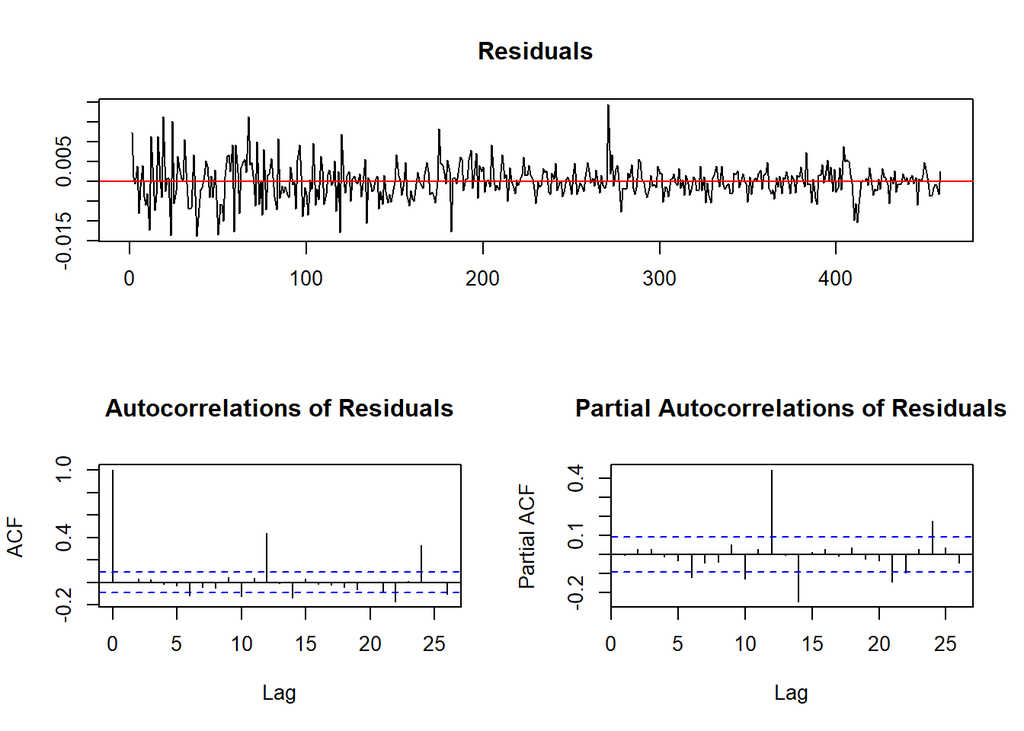

```r
plot(adf14)
```

La serie según esta prueba es estacionaria en torno a una tendencia determinística.

Hacemos la prueba KPSS cuya hipótesis nula es que la serie es estacionaria, la cual es totalmente contraria a la ADF.

```r
kp4=ur.kpss(lp.j, use.lag = 8, type = "tau") #el tau nos indica que es una prueba con términos determinísticos.
summary(kp4)
```

```
##
## #######################
## # KPSS Unit Root Test #
## #######################
##
## Test is of type: tau with 8 lags.
##
## Value of test-statistic is: 1.1174
##
## Critical value for a significance level of:
##                 10pct  5pct 2.5pct  1pct
## critical values 0.119 0.146  0.176 0.216
```

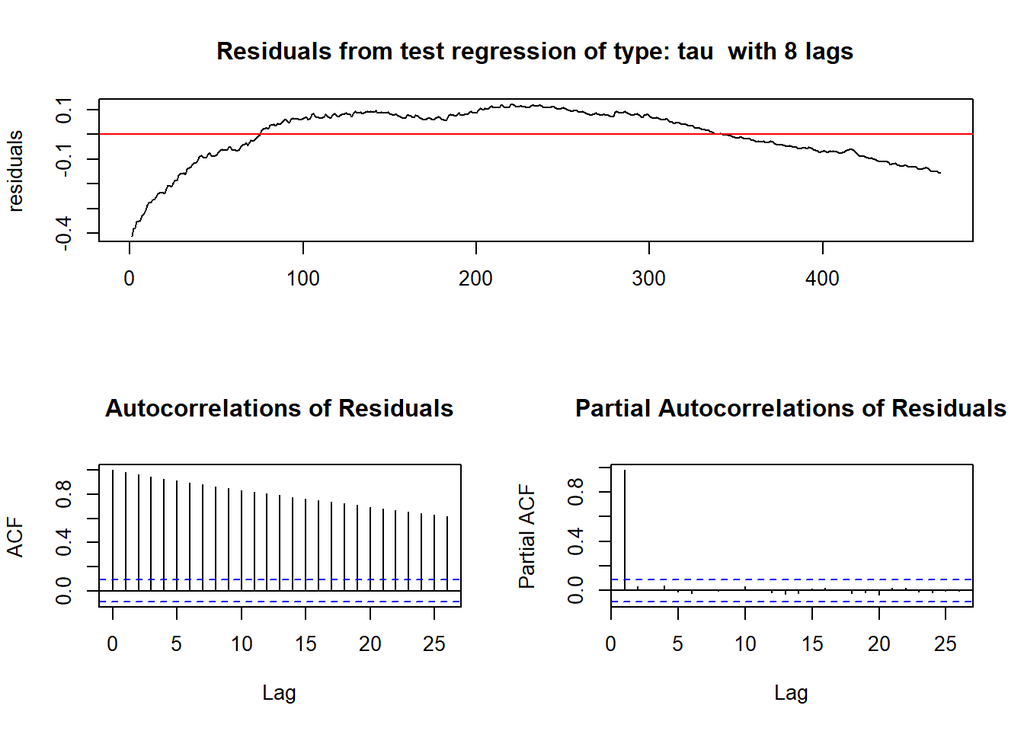

```r
plot(kp4)
```

Claramente rechazamos la hipótesis nula de estacionariedad, así que las serie no es estacionaria. Nos inclinamos poresta prueba al evaluar la gráfica de la serie y sus residuales.

Prueba sobre el logaritmo del nivel nacional de precios

Primero vamos a hacer una prueba de ADF con tendencia e intercepto.Los valores críticos de la prueba son sensibles a la inclusión de términos determinísticos, de manera que hay que determinar si la serie tiene tendencia y/o intercepto.

```r
adf15 = ur.df(lp.u,lags=7, type = "trend")
summary(adf15)
```

```
##
## ###############################################
## # Augmented Dickey-Fuller Test Unit Root Test #
## ###############################################
##
## Test regression trend
##
##
## Call:
## lm(formula = z.diff ~ z.lag.1 + 1 + tt + z.diff.lag)
##
## Residuals:
##        Min         1Q     Median         3Q        Max
## -0.0138025 -0.0012420 -0.0000171  0.0012940  0.0099978
##
## Coefficients:
##               Estimate Std. Error t value Pr(>|t|)
## (Intercept)  1.642e-02  5.968e-03   2.752  0.00617 **
## z.lag.1     -2.800e-03  1.148e-03  -2.440  0.01509 *
## tt           4.316e-06  3.426e-06   1.260  0.20848
## z.diff.lag1  5.643e-01  4.670e-02  12.085  < 2e-16 ***
## z.diff.lag2 -1.261e-01  5.363e-02  -2.351  0.01915 *
## z.diff.lag3  6.103e-02  5.393e-02   1.132  0.25841
## z.diff.lag4  6.889e-02  5.386e-02   1.279  0.20152
## z.diff.lag5 -5.128e-02  5.375e-02  -0.954  0.34054
## z.diff.lag6  5.600e-02  5.353e-02   1.046  0.29602
## z.diff.lag7  5.769e-02  4.662e-02   1.237  0.21662
## ---
## Signif. codes:  0 '***' 0.001 '**' 0.01 '*' 0.05 '.' 0.1 ' ' 1
##
## Residual standard error: 0.002363 on 450 degrees of freedom
## Multiple R-squared:  0.4943, Adjusted R-squared:  0.4842
## F-statistic: 48.87 on 9 and 450 DF,  p-value: < 2.2e-16
##
##
## Value of test-statistic is: -2.4396 9.1507 8.3577
##
## Critical values for test statistics:
##       1pct  5pct 10pct
## tau3 -3.98 -3.42 -3.13
## phi2  6.15  4.71  4.05
## phi3  8.34  6.30  5.36
```

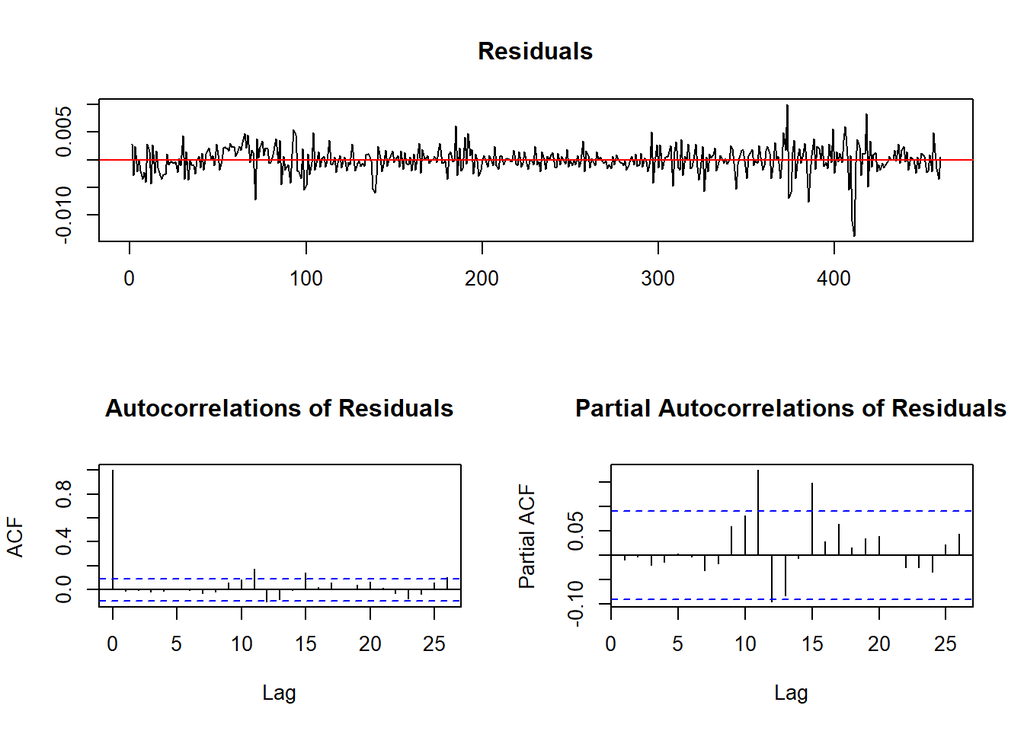

```r
plot(adf15)
```

La serie según esta prueba no es estacionaria en torno a una tendencia determinística.

Hacemos la prueba KPSS cuya hipóesis nula es que la serie es estacionaria, la cual es totalmente contraria a la ADF.

```r
kp5=ur.kpss(lp.u, use.lag = 7, type = "tau") #el tau nos indica que es una prueba con términos determinísticos.
summary(kp5)
```

```
##
## #######################
## # KPSS Unit Root Test #
## #######################
##
## Test is of type: tau with 7 lags.
##
## Value of test-statistic is: 1.2216
##
## Critical value for a significance level of:
##                 10pct  5pct 2.5pct  1pct
## critical values 0.119 0.146  0.176 0.216
```

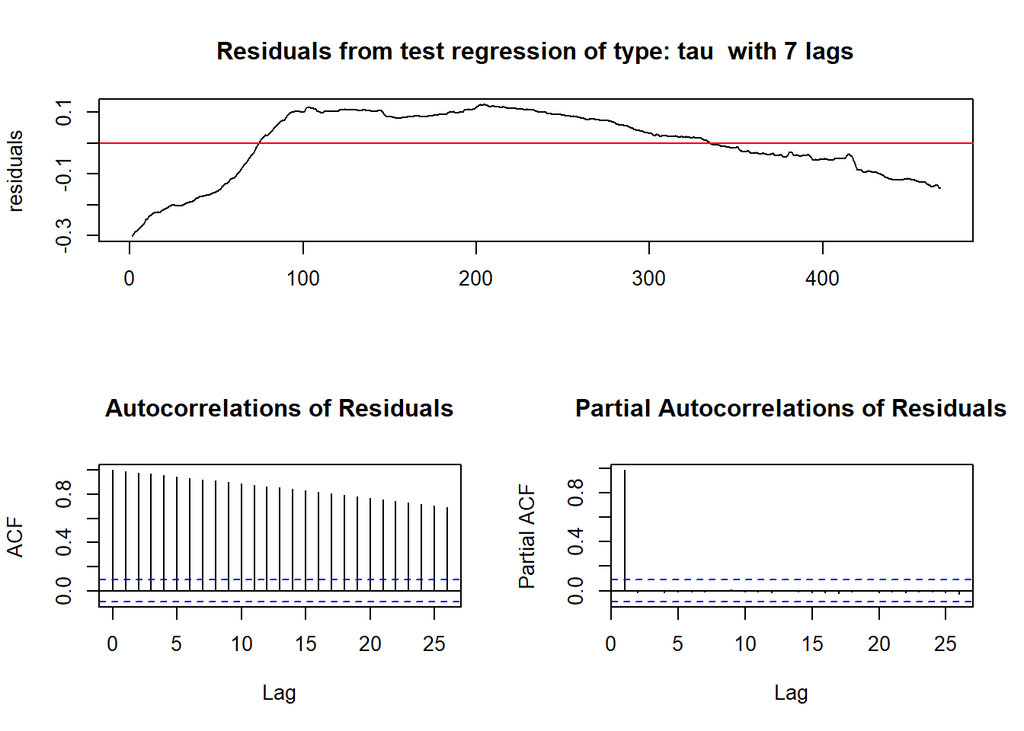

```r
plot(kp5)
```

Claramente rechazamos la hipótesis nula de estacionariedad, así que las serie no es estacionaria.

Graficamos

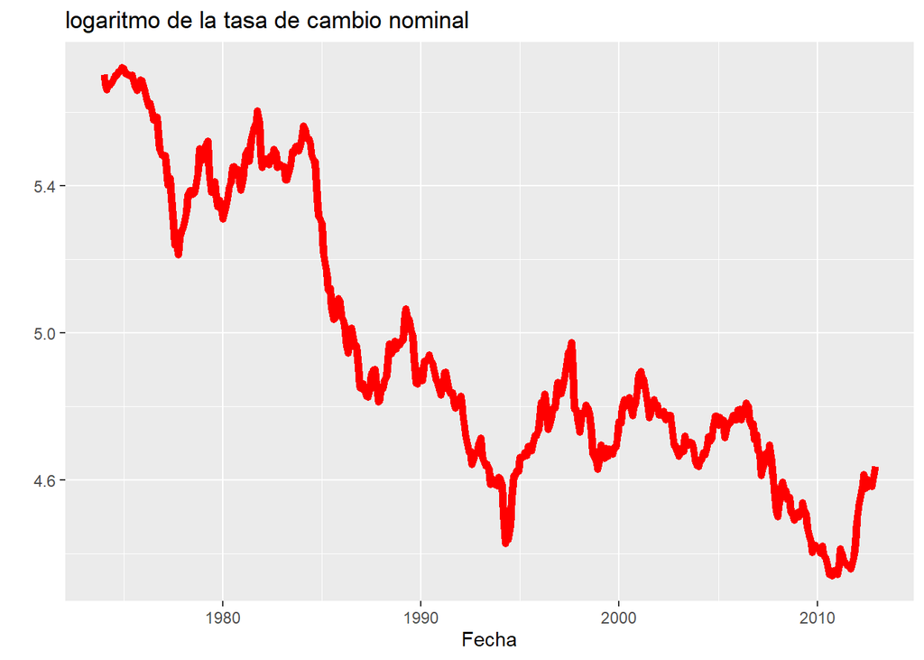

```r
x11()
autoplot(e, col="red", main = "logaritmo de la tasa de cambio nominal",xlab = "Fecha", ylab="", lwd=2)
```

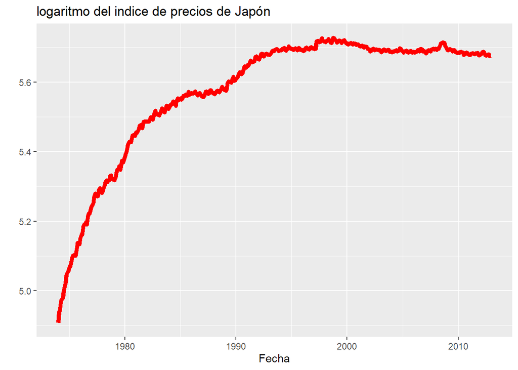

```r
autoplot(lp.j, col="red", main = "logaritmo del indice de precios de Japón",xlab = "Fecha", ylab="", lwd=2)
```

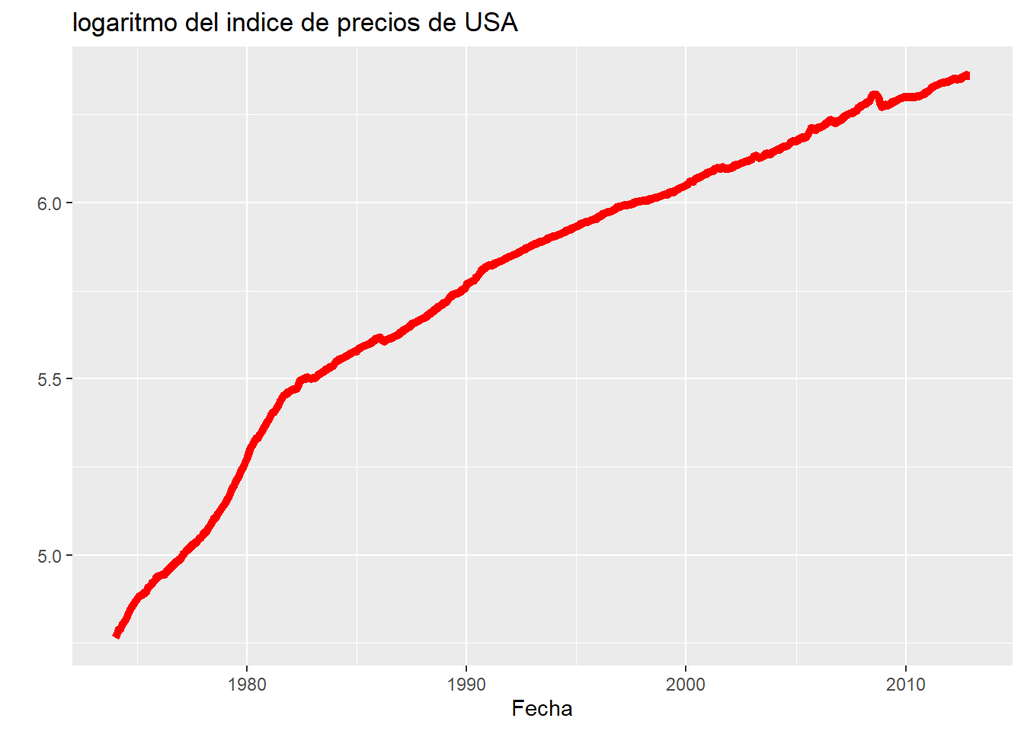

```r
autoplot(lp.u, col="red", main = "logaritmo del indice de precios de USA",xlab = "Fecha", ylab="", lwd=2)
```